# Goals for Glory: What Does It Take To Score (and Assist) as a Pro?

- Introduction
- Data Wrangling and Cleaning
- Exploratory Data Analysis
- Conclusions

## Introduction

This analysis looks at data for professional football/soccer players and matches across a variety of pro leagues. We will take a brief look at the best strikers and passers and see factors/attributes effects their ratings or performance. For strikers, we will look at the effects age has on their overall ratings as a player and their potential. For the passers, we will focus our analysis on the players who make the crucial last pass (a.k.a assist) to the eventual goal scorer and their strongest attributes.

The database (and schema, metadata, etc.) used in this analsysis can been found on kaggle [here](https://www.kaggle.com/hugomathien/soccer/data).

**The database.sqlite file used for this analysis can be found [here](https://d17h27t6h515a5.cloudfront.net/topher/2017/November/5a0a4cad_database/database.sqlite).** *Download should start automatically*

You will need to download the database to be able to run this notebook. Be sure to save the database.sqlite file in the same folder as this notebook or your project (or specify it's location in your use).

```python
# Set up import statements for all of the packages to be used.

import numpy as np
import pandas as pd
import matplotlib.pyplot as plt
import seaborn as sns
import sqlite3     # for SQLite database queries
import xml.etree.ElementTree as ET    # for XML string parsing

from scipy import stats
from datetime import datetime

%matplotlib inline
%config InlineBackend.figure_format='retina'    # improve plotting on macbook retina displays
```

## Data Wrangling and Data Cleaning

### Loading Data from SQLite Database

**Note:**  
The database has been saved locally and is accessed using the Python package sqlite3 (documentation [here](https://docs.python.org/3/library/sqlite3.html)).

```python
# Connect to sqlite database (saved locally in project dir)
database = 'database.sqlite'
conn = sqlite3.connect(database)

# query database for list of tables
query = "SELECT name FROM sqlite_master WHERE type='table';"
pd.read_sql(query, conn)
```

|  | name |
| --- | --- |
| 0 | sqlite_sequence |
| 1 | Player_Attributes |
| 2 | Player |
| 3 | Match |
| 4 | League |
| 5 | Country |
| 6 | Team |
| 7 | Team_Attributes |

We have 8 tables in total in the database. I am specifically interested in the player data. Next, check what is in **Player** and **Player_Attributes** tables.

We will also take a look at the **Match** table (more on that later).

### Get Player info and FIFA attributes

First let's take a look at the structure of the **Players** table.

```python
# query Player table
query = "SELECT * FROM Player"
temp = pd.read_sql(query, conn)
temp.sort_values('player_api_id', axis=0).head(5)
```

|  | id | player_api_id | player_name | player_fifa_api_id | birthday | height | weight |
| --- | --- | --- | --- | --- | --- | --- | --- |
| 8359 | 8372 | 2625 | Patryk Rachwal,18 | 148544 | 1981-01-27 00:00:00 | 175.26 | 154 |
| 2636 | 2639 | 2752 | Diego Mainz | 135819 | 1982-12-29 00:00:00 | 187.96 | 174 |
| 5312 | 5319 | 2768 | Jose Dorado | 110019 | 1982-07-10 00:00:00 | 180.34 | 154 |
| 4335 | 4339 | 2770 | Ignacio Gonzalez | 182861 | 1982-05-14 00:00:00 | 180.34 | 161 |
| 305 | 306 | 2790 | Alberto Rey | 110809 | 1974-02-15 00:00:00 | 175.26 | 163 |

The **Players** table contains a list of all the player names in the database along with some other useful parameters such as: birthday, height, weight, and 2 types of player IDs.

Now lets see invesitgate the structure of **Player_Attributes** table. The player attributes are taken from EA Sports FIFA player ratings which are updated periodically.

```python
# query Player_Attributes table
query = "SELECT * FROM Player_Attributes"
temp = pd.read_sql(query, conn)
temp.head(20)
```

|  | id | player_fifa_api_id | player_api_id | date | overall_rating | potential | preferred_foot | attacking_work_rate | defensive_work_rate | crossing | ... | vision | penalties | marking | standing_tackle | sliding_tackle | gk_diving | gk_handling | gk_kicking | gk_positioning | gk_reflexes |
| --- | --- | --- | --- | --- | --- | --- | --- | --- | --- | --- | --- | --- | --- | --- | --- | --- | --- | --- | --- | --- | --- |
| 0 | 1 | 218353 | 505942 | 2016-02-18 00:00:00 | 67.0 | 71.0 | right | medium | medium | 49.0 | ... | 54.0 | 48.0 | 65.0 | 69.0 | 69.0 | 6.0 | 11.0 | 10.0 | 8.0 | 8.0 |
| 1 | 2 | 218353 | 505942 | 2015-11-19 00:00:00 | 67.0 | 71.0 | right | medium | medium | 49.0 | ... | 54.0 | 48.0 | 65.0 | 69.0 | 69.0 | 6.0 | 11.0 | 10.0 | 8.0 | 8.0 |
| 2 | 3 | 218353 | 505942 | 2015-09-21 00:00:00 | 62.0 | 66.0 | right | medium | medium | 49.0 | ... | 54.0 | 48.0 | 65.0 | 66.0 | 69.0 | 6.0 | 11.0 | 10.0 | 8.0 | 8.0 |
| 3 | 4 | 218353 | 505942 | 2015-03-20 00:00:00 | 61.0 | 65.0 | right | medium | medium | 48.0 | ... | 53.0 | 47.0 | 62.0 | 63.0 | 66.0 | 5.0 | 10.0 | 9.0 | 7.0 | 7.0 |
| 4 | 5 | 218353 | 505942 | 2007-02-22 00:00:00 | 61.0 | 65.0 | right | medium | medium | 48.0 | ... | 53.0 | 47.0 | 62.0 | 63.0 | 66.0 | 5.0 | 10.0 | 9.0 | 7.0 | 7.0 |
| 5 | 6 | 189615 | 155782 | 2016-04-21 00:00:00 | 74.0 | 76.0 | left | high | medium | 80.0 | ... | 66.0 | 59.0 | 76.0 | 75.0 | 78.0 | 14.0 | 7.0 | 9.0 | 9.0 | 12.0 |
| 6 | 7 | 189615 | 155782 | 2016-04-07 00:00:00 | 74.0 | 76.0 | left | high | medium | 80.0 | ... | 66.0 | 59.0 | 76.0 | 75.0 | 78.0 | 14.0 | 7.0 | 9.0 | 9.0 | 12.0 |
| 7 | 8 | 189615 | 155782 | 2016-01-07 00:00:00 | 73.0 | 75.0 | left | high | medium | 79.0 | ... | 65.0 | 59.0 | 76.0 | 75.0 | 78.0 | 14.0 | 7.0 | 9.0 | 9.0 | 12.0 |
| 8 | 9 | 189615 | 155782 | 2015-12-24 00:00:00 | 73.0 | 75.0 | left | high | medium | 79.0 | ... | 65.0 | 59.0 | 76.0 | 75.0 | 78.0 | 14.0 | 7.0 | 9.0 | 9.0 | 12.0 |
| 9 | 10 | 189615 | 155782 | 2015-12-17 00:00:00 | 73.0 | 75.0 | left | high | medium | 79.0 | ... | 65.0 | 59.0 | 76.0 | 75.0 | 78.0 | 14.0 | 7.0 | 9.0 | 9.0 | 12.0 |
| 10 | 11 | 189615 | 155782 | 2015-10-16 00:00:00 | 73.0 | 77.0 | left | high | medium | 79.0 | ... | 65.0 | 59.0 | 76.0 | 75.0 | 78.0 | 14.0 | 7.0 | 9.0 | 9.0 | 12.0 |
| 11 | 12 | 189615 | 155782 | 2015-09-25 00:00:00 | 74.0 | 78.0 | left | high | medium | 79.0 | ... | 65.0 | 59.0 | 76.0 | 75.0 | 78.0 | 14.0 | 7.0 | 9.0 | 9.0 | 12.0 |
| 12 | 13 | 189615 | 155782 | 2015-09-21 00:00:00 | 73.0 | 77.0 | left | medium | medium | 79.0 | ... | 65.0 | 59.0 | 76.0 | 75.0 | 78.0 | 14.0 | 7.0 | 9.0 | 9.0 | 12.0 |
| 13 | 14 | 189615 | 155782 | 2015-01-09 00:00:00 | 71.0 | 75.0 | left | medium | medium | 78.0 | ... | 64.0 | 58.0 | 73.0 | 72.0 | 72.0 | 13.0 | 6.0 | 8.0 | 8.0 | 11.0 |
| 14 | 15 | 189615 | 155782 | 2014-12-05 00:00:00 | 71.0 | 77.0 | left | medium | medium | 78.0 | ... | 64.0 | 58.0 | 73.0 | 72.0 | 72.0 | 13.0 | 6.0 | 8.0 | 8.0 | 11.0 |
| 15 | 16 | 189615 | 155782 | 2014-11-07 00:00:00 | 71.0 | 77.0 | left | medium | medium | 78.0 | ... | 64.0 | 58.0 | 73.0 | 72.0 | 72.0 | 13.0 | 6.0 | 8.0 | 8.0 | 11.0 |
| 16 | 17 | 189615 | 155782 | 2014-09-18 00:00:00 | 70.0 | 77.0 | left | medium | medium | 77.0 | ... | 64.0 | 58.0 | 73.0 | 72.0 | 72.0 | 13.0 | 6.0 | 8.0 | 8.0 | 11.0 |
| 17 | 18 | 189615 | 155782 | 2014-05-02 00:00:00 | 70.0 | 79.0 | left | medium | medium | 77.0 | ... | 64.0 | 58.0 | 73.0 | 72.0 | 72.0 | 13.0 | 6.0 | 8.0 | 8.0 | 11.0 |
| 18 | 19 | 189615 | 155782 | 2014-04-04 00:00:00 | 70.0 | 79.0 | left | medium | medium | 77.0 | ... | 64.0 | 58.0 | 73.0 | 72.0 | 72.0 | 13.0 | 6.0 | 8.0 | 8.0 | 11.0 |
| 19 | 20 | 189615 | 155782 | 2014-03-14 00:00:00 | 70.0 | 79.0 | left | medium | medium | 77.0 | ... | 61.0 | 58.0 | 73.0 | 72.0 | 72.0 | 13.0 | 6.0 | 8.0 | 8.0 | 11.0 |

20 rows × 42 columns

WOAH, that is a lot of attributes for each individual player! The **Player_Attributes** table lists all of the attributes identified in the video game FIFA (by EA sports) for each player. We also see common player IDs as was found in the **Players** table, great!

*What's going on here???*

Judging by the *date* column, it looks as though player attributes are updated as time goes on. This could be useful if we wanted to get an idea of player "evolultion" (i.e. player improvement) over time, but we will leave this for another analysis. For now, I am only interested in the most up-to-date attributes and rating for each player.

#### Joining Tables from Database

It would be useful to have all of the player data in one Pandas Dataframe for ease of use in our analysis. Let's join the **Player** and **Player_Attributes** tables in our SQL query to acheive this.

We will also address the multiple entries for each *player_api_id* that occur in the **Player_Attributes** table in the query, only using the latest entry in the database for any player in this analysis.

```python
# The backslashes, \ , in the query below are used to keep the string continuing onto the next line
# for easier reading of the  query structure. They have no purpose in the query itself!

# NOTE:
# You cannot have spaces after the "\" on each line of the query. If you do, it will "break" the string, and the query will not run!
# MAX(pa.date) ensures we only query the latest values by date for each player (ingore older player attributes)

query = "WITH t1 AS (SELECT pa.player_api_id player_api_id_attr, pa.overall_rating, pa.potential, MAX(pa.date) rating_date,\
                        pa.preferred_foot, pa.attacking_work_rate, pa.defensive_work_rate,\
                        pa.crossing, pa.finishing, pa.heading_accuracy, short_passing, pa.volleys,\
                        pa.dribbling, pa.curve, pa.free_kick_accuracy, pa.long_passing, pa.ball_control,\
                        pa.acceleration, pa.sprint_speed, pa.agility, pa.reactions, pa.balance, pa.shot_power,\
                        pa.jumping, pa.stamina, pa.strength, pa.long_shots, pa.aggression, pa.interceptions,\
                        pa.positioning, pa.vision, pa.penalties, pa.marking, pa.standing_tackle, pa.sliding_tackle\
                        FROM Player_Attributes pa\
                        GROUP BY 1\
                        ORDER BY 1)\
        SELECT p.*, t1.*\
        FROM Player p\
        JOIN t1\
        ON p.player_api_id = t1.player_api_id_attr"

player = pd.read_sql(query, conn)
player.head(5)
```

|  | id | player_api_id | player_name | player_fifa_api_id | birthday | height | weight | player_api_id_attr | overall_rating | potential | ... | strength | long_shots | aggression | interceptions | positioning | vision | penalties | marking | standing_tackle | sliding_tackle |
| --- | --- | --- | --- | --- | --- | --- | --- | --- | --- | --- | --- | --- | --- | --- | --- | --- | --- | --- | --- | --- | --- |
| 0 | 8372 | 2625 | Patryk Rachwal,18 | 148544 | 1981-01-27 00:00:00 | 175.26 | 154 | 2625 | 61 | 61 | ... | 56 | 54 | 71 | 64 | 49 | 55.0 | 66 | 62 | 63 | 54.0 |
| 1 | 2639 | 2752 | Diego Mainz | 135819 | 1982-12-29 00:00:00 | 187.96 | 174 | 2752 | 72 | 72 | ... | 85 | 20 | 84 | 71 | 34 | 55.0 | 38 | 72 | 74 | 67.0 |
| 2 | 5319 | 2768 | Jose Dorado | 110019 | 1982-07-10 00:00:00 | 180.34 | 154 | 2768 | 74 | 74 | ... | 72 | 20 | 65 | 80 | 40 | 60.0 | 16 | 76 | 76 | 77.0 |
| 3 | 4339 | 2770 | Ignacio Gonzalez | 182861 | 1982-05-14 00:00:00 | 180.34 | 161 | 2770 | 69 | 69 | ... | 61 | 74 | 64 | 41 | 71 | 68.0 | 69 | 33 | 43 | 25.0 |
| 4 | 306 | 2790 | Alberto Rey | 110809 | 1974-02-15 00:00:00 | 175.26 | 163 | 2790 | 67 | 77 | ... | 67 | 42 | 74 | 68 | 56 | 60.0 | 54 | 70 | 73 | 69.0 |

5 rows × 42 columns

There are a few columns we aren't interested in for this analysis, let's drop those now. We also drop the *player_api_id_attr* column, as it is a copy of the *player_api_id* column (this is a result of the SQL query).

```python
player = player.drop(['id', 'player_api_id_attr', 'player_fifa_api_id', 'rating_date'], axis=1)
player.head(20)
```

|  | player_api_id | player_name | birthday | height | weight | overall_rating | potential | preferred_foot | attacking_work_rate | defensive_work_rate | ... | strength | long_shots | aggression | interceptions | positioning | vision | penalties | marking | standing_tackle | sliding_tackle |
| --- | --- | --- | --- | --- | --- | --- | --- | --- | --- | --- | --- | --- | --- | --- | --- | --- | --- | --- | --- | --- | --- |
| 0 | 2625 | Patryk Rachwal,18 | 1981-01-27 00:00:00 | 175.26 | 154 | 61 | 61 | right | medium | medium | ... | 56 | 54 | 71 | 64 | 49 | 55.0 | 66 | 62 | 63 | 54.0 |
| 1 | 2752 | Diego Mainz | 1982-12-29 00:00:00 | 187.96 | 174 | 72 | 72 | right | medium | medium | ... | 85 | 20 | 84 | 71 | 34 | 55.0 | 38 | 72 | 74 | 67.0 |
| 2 | 2768 | Jose Dorado | 1982-07-10 00:00:00 | 180.34 | 154 | 74 | 74 | left | medium | medium | ... | 72 | 20 | 65 | 80 | 40 | 60.0 | 16 | 76 | 76 | 77.0 |
| 3 | 2770 | Ignacio Gonzalez | 1982-05-14 00:00:00 | 180.34 | 161 | 69 | 69 | right | medium | low | ... | 61 | 74 | 64 | 41 | 71 | 68.0 | 69 | 33 | 43 | 25.0 |
| 4 | 2790 | Alberto Rey | 1974-02-15 00:00:00 | 175.26 | 163 | 67 | 77 | left | None | 7 | ... | 67 | 42 | 74 | 68 | 56 | 60.0 | 54 | 70 | 73 | 69.0 |
| 5 | 2796 | Javier Jimenez | 1987-06-08 00:00:00 | 182.88 | 170 | 69 | 69 | right | medium | medium | ... | 53 | 11 | 28 | 25 | 13 | 35.0 | 20 | 14 | 14 | 15.0 |
| 6 | 2802 | Pablo Hernandez | 1985-04-11 00:00:00 | 172.72 | 159 | 76 | 76 | right | high | medium | ... | 51 | 77 | 54 | 49 | 73 | 74.0 | 72 | 42 | 47 | 36.0 |
| 7 | 2805 | Ruben Perez | 1989-04-26 00:00:00 | 177.80 | 159 | 76 | 77 | right | medium | medium | ... | 77 | 72 | 82 | 84 | 59 | 76.0 | 51 | 61 | 82 | 65.0 |
| 8 | 2857 | Ivan Perez | 1985-11-16 00:00:00 | 172.72 | 143 | 65 | 67 | left | medium | low | ... | 58 | 65 | 45 | 41 | 59 | 69.0 | 60 | 28 | 36 | 23.0 |
| 9 | 2862 | Vicente Sanchez | 1979-12-07 00:00:00 | 170.18 | 146 | 72 | 72 | left | high | medium | ... | 55 | 69 | 41 | 38 | 69 | 67.0 | 75 | 22 | 18 | 20.0 |
| 10 | 2907 | Gregory Lacombe | 1982-01-11 00:00:00 | 165.10 | 128 | 65 | 65 | left | medium | medium | ... | 31 | 52 | 56 | 51 | 61 | 73.0 | 53 | 29 | 41 | 55.0 |
| 11 | 2973 | Ugur Inceman | 1981-05-25 00:00:00 | 182.88 | 176 | 68 | 68 | right | medium | medium | ... | 72 | 72 | 74 | 68 | 62 | 66.0 | 54 | 61 | 62 | 48.0 |
| 12 | 2977 | David Rivas Rodriguez | 1978-12-02 00:00:00 | 190.50 | 187 | 62 | 62 | right | low | medium | ... | 91 | 45 | 73 | 58 | 32 | 48.0 | 34 | 62 | 65 | 51.0 |
| 13 | 2983 | Jorge Molina | 1982-04-22 00:00:00 | 187.96 | 192 | 75 | 75 | right | medium | medium | ... | 91 | 72 | 76 | 41 | 84 | 58.0 | 78 | 30 | 32 | 19.0 |
| 14 | 2984 | Sergio Aragones | 1977-02-01 00:00:00 | 182.88 | 176 | 65 | 65 | right | medium | medium | ... | 68 | 25 | 35 | 21 | 25 | 25.0 | 29 | 25 | 25 | 25.0 |
| 15 | 3140 | Alexandre Hauw | 1982-01-22 00:00:00 | 175.26 | 150 | 66 | 71 | left | None | o | ... | 67 | 66 | 68 | 69 | 30 | 68.0 | 63 | 57 | 62 | 61.0 |
| 16 | 3204 | Marat Izmailov | 1982-09-21 00:00:00 | 170.18 | 154 | 73 | 73 | right | medium | low | ... | 62 | 73 | 56 | 45 | 67 | 73.0 | 69 | 23 | 43 | 31.0 |
| 17 | 3263 | Kelly Berville | 1978-01-05 00:00:00 | 177.80 | 172 | 67 | 68 | left | None | _0 | ... | 75 | 37 | 71 | 65 | 63 | NaN | 64 | 65 | 66 | NaN |
| 18 | 3264 | Abdelmalek Cherrad | 1981-01-14 00:00:00 | 185.42 | 165 | 62 | 73 | right | None | _0 | ... | 61 | 59 | 52 | 30 | 74 | 66.0 | 41 | 30 | 34 | 36.0 |
| 19 | 3316 | Oscar Sanchez | 1979-12-19 00:00:00 | 180.34 | 159 | 67 | 67 | left | high | medium | ... | 69 | 57 | 80 | 64 | 63 | 60.0 | 57 | 55 | 66 | 70.0 |

20 rows × 38 columns

It looks like the attacking/defensive_work_rate columns have some error values mixed amongst the standard inputs of low, medium, high. Let's set these error values to NaN and change the string inputs to numeric values, where:

low = 1  
medium = 2  
high = 3

```python
### ATTACKING_WORK_RATE
# assign low, medium, high numeric values
player.attacking_work_rate.replace(to_replace='low', value=1, inplace=True)
player.attacking_work_rate.replace(to_replace='medium', value=2, inplace=True)
player.attacking_work_rate.replace(to_replace='high', value=3, inplace=True)

# set to numeric values, set non-numeric like string to NaN
player['attacking_work_rate'] = pd.to_numeric(player.attacking_work_rate, errors = 'coerce')
player.attacking_work_rate.mask(player.attacking_work_rate > 3, np.NaN, inplace=True)    # set any values outside valid range (1-3) as NaN
player.attacking_work_rate.mask(player.attacking_work_rate < 0, np.NaN, inplace=True)    # set any values outside valid range (1-3) as NaN

### DEFENSIVE_WORK_RATE
# assign low, medium, high numeric values
player.defensive_work_rate.replace(to_replace='low', value=1, inplace=True)
player.defensive_work_rate.replace(to_replace='medium', value=2, inplace=True)
player.defensive_work_rate.replace(to_replace='high', value=3, inplace=True)

# set to numeric values, set non-numeric like string to NaN
player['defensive_work_rate'] = pd.to_numeric(player.defensive_work_rate, errors = 'coerce')
player.defensive_work_rate.mask(player.defensive_work_rate > 3.0, np.NaN, inplace=True)    # set any values outside valid range (1-3) as NaN
player.defensive_work_rate.mask(player.defensive_work_rate < 0, np.NaN, inplace=True)    # set any values outside valid range (1-3) as NaN

player.head(20)
```

|  | player_api_id | player_name | birthday | height | weight | overall_rating | potential | preferred_foot | attacking_work_rate | defensive_work_rate | ... | strength | long_shots | aggression | interceptions | positioning | vision | penalties | marking | standing_tackle | sliding_tackle |
| --- | --- | --- | --- | --- | --- | --- | --- | --- | --- | --- | --- | --- | --- | --- | --- | --- | --- | --- | --- | --- | --- |
| 0 | 2625 | Patryk Rachwal,18 | 1981-01-27 00:00:00 | 175.26 | 154 | 61 | 61 | right | 2.0 | 2.0 | ... | 56 | 54 | 71 | 64 | 49 | 55.0 | 66 | 62 | 63 | 54.0 |
| 1 | 2752 | Diego Mainz | 1982-12-29 00:00:00 | 187.96 | 174 | 72 | 72 | right | 2.0 | 2.0 | ... | 85 | 20 | 84 | 71 | 34 | 55.0 | 38 | 72 | 74 | 67.0 |
| 2 | 2768 | Jose Dorado | 1982-07-10 00:00:00 | 180.34 | 154 | 74 | 74 | left | 2.0 | 2.0 | ... | 72 | 20 | 65 | 80 | 40 | 60.0 | 16 | 76 | 76 | 77.0 |
| 3 | 2770 | Ignacio Gonzalez | 1982-05-14 00:00:00 | 180.34 | 161 | 69 | 69 | right | 2.0 | 1.0 | ... | 61 | 74 | 64 | 41 | 71 | 68.0 | 69 | 33 | 43 | 25.0 |
| 4 | 2790 | Alberto Rey | 1974-02-15 00:00:00 | 175.26 | 163 | 67 | 77 | left | NaN | NaN | ... | 67 | 42 | 74 | 68 | 56 | 60.0 | 54 | 70 | 73 | 69.0 |
| 5 | 2796 | Javier Jimenez | 1987-06-08 00:00:00 | 182.88 | 170 | 69 | 69 | right | 2.0 | 2.0 | ... | 53 | 11 | 28 | 25 | 13 | 35.0 | 20 | 14 | 14 | 15.0 |
| 6 | 2802 | Pablo Hernandez | 1985-04-11 00:00:00 | 172.72 | 159 | 76 | 76 | right | 3.0 | 2.0 | ... | 51 | 77 | 54 | 49 | 73 | 74.0 | 72 | 42 | 47 | 36.0 |
| 7 | 2805 | Ruben Perez | 1989-04-26 00:00:00 | 177.80 | 159 | 76 | 77 | right | 2.0 | 2.0 | ... | 77 | 72 | 82 | 84 | 59 | 76.0 | 51 | 61 | 82 | 65.0 |
| 8 | 2857 | Ivan Perez | 1985-11-16 00:00:00 | 172.72 | 143 | 65 | 67 | left | 2.0 | 1.0 | ... | 58 | 65 | 45 | 41 | 59 | 69.0 | 60 | 28 | 36 | 23.0 |
| 9 | 2862 | Vicente Sanchez | 1979-12-07 00:00:00 | 170.18 | 146 | 72 | 72 | left | 3.0 | 2.0 | ... | 55 | 69 | 41 | 38 | 69 | 67.0 | 75 | 22 | 18 | 20.0 |
| 10 | 2907 | Gregory Lacombe | 1982-01-11 00:00:00 | 165.10 | 128 | 65 | 65 | left | 2.0 | 2.0 | ... | 31 | 52 | 56 | 51 | 61 | 73.0 | 53 | 29 | 41 | 55.0 |
| 11 | 2973 | Ugur Inceman | 1981-05-25 00:00:00 | 182.88 | 176 | 68 | 68 | right | 2.0 | 2.0 | ... | 72 | 72 | 74 | 68 | 62 | 66.0 | 54 | 61 | 62 | 48.0 |
| 12 | 2977 | David Rivas Rodriguez | 1978-12-02 00:00:00 | 190.50 | 187 | 62 | 62 | right | 1.0 | 2.0 | ... | 91 | 45 | 73 | 58 | 32 | 48.0 | 34 | 62 | 65 | 51.0 |
| 13 | 2983 | Jorge Molina | 1982-04-22 00:00:00 | 187.96 | 192 | 75 | 75 | right | 2.0 | 2.0 | ... | 91 | 72 | 76 | 41 | 84 | 58.0 | 78 | 30 | 32 | 19.0 |
| 14 | 2984 | Sergio Aragones | 1977-02-01 00:00:00 | 182.88 | 176 | 65 | 65 | right | 2.0 | 2.0 | ... | 68 | 25 | 35 | 21 | 25 | 25.0 | 29 | 25 | 25 | 25.0 |
| 15 | 3140 | Alexandre Hauw | 1982-01-22 00:00:00 | 175.26 | 150 | 66 | 71 | left | NaN | NaN | ... | 67 | 66 | 68 | 69 | 30 | 68.0 | 63 | 57 | 62 | 61.0 |
| 16 | 3204 | Marat Izmailov | 1982-09-21 00:00:00 | 170.18 | 154 | 73 | 73 | right | 2.0 | 1.0 | ... | 62 | 73 | 56 | 45 | 67 | 73.0 | 69 | 23 | 43 | 31.0 |
| 17 | 3263 | Kelly Berville | 1978-01-05 00:00:00 | 177.80 | 172 | 67 | 68 | left | NaN | NaN | ... | 75 | 37 | 71 | 65 | 63 | NaN | 64 | 65 | 66 | NaN |
| 18 | 3264 | Abdelmalek Cherrad | 1981-01-14 00:00:00 | 185.42 | 165 | 62 | 73 | right | NaN | NaN | ... | 61 | 59 | 52 | 30 | 74 | 66.0 | 41 | 30 | 34 | 36.0 |
| 19 | 3316 | Oscar Sanchez | 1979-12-19 00:00:00 | 180.34 | 159 | 67 | 67 | left | 3.0 | 2.0 | ... | 69 | 57 | 80 | 64 | 63 | 60.0 | 57 | 55 | 66 | 70.0 |

20 rows × 38 columns

Let's check the datatypes for our dataframe to make sure each column is in the format we want for further analysis.

```python
player.info()
```

```
<class 'pandas.core.frame.DataFrame'>
RangeIndex: 11060 entries, 0 to 11059
Data columns (total 38 columns):
player_api_id          11060 non-null int64
player_name            11060 non-null object
birthday               11060 non-null object
height                 11060 non-null float64
weight                 11060 non-null int64
overall_rating         11060 non-null int64
potential              11060 non-null int64
preferred_foot         11060 non-null object
attacking_work_rate    9907 non-null float64
defensive_work_rate    10022 non-null float64
crossing               11060 non-null int64
finishing              11060 non-null int64
heading_accuracy       11060 non-null int64
short_passing          11060 non-null int64
volleys                10582 non-null float64
dribbling              11060 non-null int64
curve                  10582 non-null float64
free_kick_accuracy     11060 non-null int64
long_passing           11060 non-null int64
ball_control           11060 non-null int64
acceleration           11060 non-null int64
sprint_speed           11060 non-null int64
agility                10582 non-null float64
reactions              11060 non-null int64
balance                10582 non-null float64
shot_power             11060 non-null int64
jumping                10582 non-null float64
stamina                11060 non-null int64
strength               11060 non-null int64
long_shots             11060 non-null int64
aggression             11060 non-null int64
interceptions          11060 non-null int64
positioning            11060 non-null int64
vision                 10582 non-null float64
penalties              11060 non-null int64
marking                11060 non-null int64
standing_tackle        11060 non-null int64
sliding_tackle         10582 non-null float64
dtypes: float64(10), int64(25), object(3)
memory usage: 3.2+ MB
```

The data types look reasonable for now, except for the *birthday* column. This is currently stored as a string, but a datetime is preferably.

```python
player['birthday'] = pd.to_datetime(player['birthday'])
player.info()
```

```
<class 'pandas.core.frame.DataFrame'>
RangeIndex: 11060 entries, 0 to 11059
Data columns (total 38 columns):
player_api_id          11060 non-null int64
player_name            11060 non-null object
birthday               11060 non-null datetime64[ns]
height                 11060 non-null float64
weight                 11060 non-null int64
overall_rating         11060 non-null int64
potential              11060 non-null int64
preferred_foot         11060 non-null object
attacking_work_rate    9907 non-null float64
defensive_work_rate    10022 non-null float64
crossing               11060 non-null int64
finishing              11060 non-null int64
heading_accuracy       11060 non-null int64
short_passing          11060 non-null int64
volleys                10582 non-null float64
dribbling              11060 non-null int64
curve                  10582 non-null float64
free_kick_accuracy     11060 non-null int64
long_passing           11060 non-null int64
ball_control           11060 non-null int64
acceleration           11060 non-null int64
sprint_speed           11060 non-null int64
agility                10582 non-null float64
reactions              11060 non-null int64
balance                10582 non-null float64
shot_power             11060 non-null int64
jumping                10582 non-null float64
stamina                11060 non-null int64
strength               11060 non-null int64
long_shots             11060 non-null int64
aggression             11060 non-null int64
interceptions          11060 non-null int64
positioning            11060 non-null int64
vision                 10582 non-null float64
penalties              11060 non-null int64
marking                11060 non-null int64
standing_tackle        11060 non-null int64
sliding_tackle         10582 non-null float64
dtypes: datetime64[ns](1), float64(10), int64(25), object(2)
memory usage: 3.2+ MB
```

Good, we have fixed the birthday column to datetime. A quick summary of descriptive statistics for each column is in order to quickly to indicate any outlying values.

```python
player.describe()
```

|  | player_api_id | height | weight | overall_rating | potential | attacking_work_rate | defensive_work_rate | crossing | finishing | heading_accuracy | ... | strength | long_shots | aggression | interceptions | positioning | vision | penalties | marking | standing_tackle | sliding_tackle |
| --- | --- | --- | --- | --- | --- | --- | --- | --- | --- | --- | --- | --- | --- | --- | --- | --- | --- | --- | --- | --- | --- |
| count | 11060.000000 | 11060.000000 | 11060.000000 | 11060.000000 | 11060.000000 | 9907.000000 | 10022.000000 | 11060.000000 | 11060.000000 | 11060.000000 | ... | 11060.000000 | 11060.000000 | 11060.000000 | 11060.000000 | 11060.000000 | 10582.000000 | 11060.000000 | 11060.000000 | 11060.000000 | 10582.000000 |
| mean | 156582.427215 | 181.867445 | 168.380289 | 67.965009 | 71.040054 | 2.182699 | 2.046897 | 53.975769 | 48.167993 | 56.795027 | ... | 68.198192 | 52.042134 | 61.008590 | 51.045660 | 53.350452 | 56.286241 | 53.446745 | 47.075678 | 50.545750 | 48.061992 |
| std | 160713.700624 | 6.369201 | 14.990217 | 6.318386 | 6.217195 | 0.513232 | 0.519451 | 17.471560 | 18.963159 | 16.715576 | ... | 11.575281 | 18.439188 | 16.254893 | 19.896463 | 19.046627 | 14.548265 | 15.890460 | 21.598992 | 21.722335 | 21.729183 |
| min | 2625.000000 | 157.480000 | 117.000000 | 42.000000 | 49.000000 | 1.000000 | 0.000000 | 6.000000 | 3.000000 | 7.000000 | ... | 21.000000 | 6.000000 | 11.000000 | 6.000000 | 3.000000 | 3.000000 | 7.000000 | 3.000000 | 6.000000 | 5.000000 |
| 25% | 35555.500000 | 177.800000 | 159.000000 | 64.000000 | 67.000000 | 2.000000 | 2.000000 | 44.000000 | 33.000000 | 50.000000 | ... | 61.000000 | 40.000000 | 52.000000 | 32.000000 | 41.000000 | 47.000000 | 44.000000 | 25.000000 | 29.000000 | 25.000000 |
| 50% | 96619.500000 | 182.880000 | 168.000000 | 68.000000 | 71.000000 | 2.000000 | 2.000000 | 58.000000 | 51.000000 | 60.000000 | ... | 69.000000 | 57.000000 | 64.000000 | 56.000000 | 58.000000 | 58.000000 | 55.000000 | 53.000000 | 58.000000 | 55.000000 |
| 75% | 212470.500000 | 185.420000 | 179.000000 | 72.000000 | 75.000000 | 2.000000 | 2.000000 | 67.000000 | 64.000000 | 68.000000 | ... | 76.000000 | 66.000000 | 73.000000 | 68.000000 | 67.250000 | 67.000000 | 65.000000 | 66.000000 | 69.000000 | 67.000000 |
| max | 750584.000000 | 208.280000 | 243.000000 | 94.000000 | 94.000000 | 3.000000 | 3.000000 | 92.000000 | 95.000000 | 95.000000 | ... | 96.000000 | 93.000000 | 94.000000 | 95.000000 | 96.000000 | 94.000000 | 96.000000 | 90.000000 | 91.000000 | 95.000000 |

8 rows × 35 columns

Based on the metadata for the dataset on [kaggle](https://www.kaggle.com/hugomathien/soccer/data), the goal and assist data is stored in the **Match** table, in the column *goal*. Let's take a look at this next to see what we find.

### Get Match & Goal Data

Let's start by querying the Match table to see what data is available.

**NOTE**:

1. I have removed rows from the table where there is no goal data (14,217 rows total). This leaves 11,762 rows of where goal data is available. The reason for this missing goal data in the origianl SQLite database is unknown.
2. NULL values were NOT replaced with any other value (e.g., replaced with mean) due to the sheer number of rows with missing data for goals (> 50% of total rows). Any cleaning of the missing data would could skew the distribution of data or could misrepresent any individual player's stats which I do not believe is appropriate in this analysis.

I am aware that this missing goal data may be in a sense discrediting goals/assits for players where they actually scored or assisted but no match goal data was recorded. However, due to the number rows missing goal data, I think any cleaning or replacement of missing values would do more harm than good to the analysis.

```python
# query the match table (again, "\" is for string continuation)
query = "SELECT * \
            FROM Match\
            WHERE goal IS NOT NULL"

match = pd.read_sql(query,conn)
match.head()
```

|  | id | country_id | league_id | season | stage | date | match_api_id | home_team_api_id | away_team_api_id | home_team_goal | ... | SJA | VCH | VCD | VCA | GBH | GBD | GBA | BSH | BSD | BSA |
| --- | --- | --- | --- | --- | --- | --- | --- | --- | --- | --- | --- | --- | --- | --- | --- | --- | --- | --- | --- | --- | --- |
| 0 | 1729 | 1729 | 1729 | 2008/2009 | 1 | 2008-08-17 00:00:00 | 489042 | 10260 | 10261 | 1 | ... | 10.00 | 1.28 | 5.5 | 12.00 | 1.30 | 4.75 | 10.0 | 1.29 | 4.50 | 11.00 |
| 1 | 1730 | 1729 | 1729 | 2008/2009 | 1 | 2008-08-16 00:00:00 | 489043 | 9825 | 8659 | 1 | ... | 12.00 | 1.25 | 6.0 | 13.00 | 1.22 | 5.50 | 13.0 | 1.22 | 5.00 | 13.00 |
| 2 | 1731 | 1729 | 1729 | 2008/2009 | 1 | 2008-08-16 00:00:00 | 489044 | 8472 | 8650 | 0 | ... | 1.73 | 5.50 | 3.8 | 1.65 | 5.00 | 3.40 | 1.7 | 4.50 | 3.40 | 1.73 |
| 3 | 1732 | 1729 | 1729 | 2008/2009 | 1 | 2008-08-16 00:00:00 | 489045 | 8654 | 8528 | 2 | ... | 3.75 | 1.90 | 3.5 | 4.35 | 1.91 | 3.25 | 4.0 | 1.91 | 3.25 | 3.80 |
| 4 | 1733 | 1729 | 1729 | 2008/2009 | 1 | 2008-08-17 00:00:00 | 489046 | 10252 | 8456 | 4 | ... | 3.75 | 1.90 | 3.5 | 4.35 | 1.91 | 3.25 | 4.0 | 1.91 | 3.30 | 3.75 |

5 rows × 115 columns

WOAH (again), that is a LOT of columns storing different match data. We are interested in the goals column, so most of the other columns in this table will not be used.

But before we dig deeper, it will be a good idea to see what time period the match data is available for (i.e., one season, 2 seasons, more?).

```python
print("The first match in the database was on:", match.date.min())   # first match in database
print("The last match in the database was on:", match.date.max())   # last match in database
```

```
The first match in the database was on: 2008-08-15 00:00:00
The last match in the database was on: 2016-05-25 00:00:00
```

Looks like there is roughly 8 years of match data. How does this effect our analysis? Are we interested in stats or relationships for a single season, or a longer period of time?

I have decided to use all of the match and goal data across the 8 years. This will provide a better idea of how players have performed over the duration of their careers and diminish season-to-season variations in player performance.

Now, let's take a look at look at the *goals* column to see what the data looks like...

```python
match.goal.head()
```

```
0    <goal><value><comment>n</comment><stats><goals...
1    <goal><value><comment>n</comment><stats><goals...
2    <goal><value><comment>n</comment><stats><goals...
3    <goal><value><comment>n</comment><stats><goals...
4    <goal><value><comment>n</comment><stats><goals...
Name: goal, dtype: object
```

These data points look to be composed of strange structure of strings. What does an individual entry look like?

```python
match.goal[0]
```

```
'<goal><value><comment>n</comment><stats><goals>1</goals><shoton>1</shoton></stats><event_incident_typefk>406</event_incident_typefk><elapsed>22</elapsed><player2>38807</player2><subtype>header</subtype><player1>37799</player1><sortorder>5</sortorder><team>10261</team><id>378998</id><n>295</n><type>…
```

Hmmm... looks like the goal data is stored in an XML string. This will require some parsing/cleaning to get useable data, which we will work thourgh below.

#### Making sense of the goal column XML strings

After some investigation, and looking through the associated forums on kaggle for this dataset, I found:

> **Knut Behrends wrote (see [link](https://www.kaggle.com/hugomathien/soccer/discussion/44871#253969))** :

> "With regard to the XML fragment, I think 'player1' element means this guy scored, 'player2' made the assist. I've looked it up for this game, Manchester United vs Newcastle, first game in Season 2008/2009, the player IDs are correct."

Much thanks to *Knut Behrends* for his efforts to confirm the meanings of "player1" and "player2" in the XML strings. I will assume his findings are correct for all matches included in this analysis.

#### Cleaning up the goal data

For each goal scored in a match, the XML string lists the scoring player (player1) and the assist (player2). So we need to read through each string of XML for every match, and append each goal scored and each assist to a list of goal scorers and assisting players (or somtheing similar).

In order to parse the XML to pull out the relevant *player1* and *player2* occurences (as described by Knut Behrends), we will need to use Python's built in XML package (see [docs](https://docs.python.org/2/library/xml.etree.elementtree.html)). A good tutorial on using XML, by Charles Severance at the University of Michigan, can be found [here](https://www.youtube.com/watch?v=3OnGNUPxlho). This really helped me understand how to use the XML package.

##### Step 1: Parsing XML Data

We will need some helper functions to parse the XML data in each cell. Let's lay them out below:

```python
# define helper functions
def find_goal_players(xml_string):
    '''This function parses XML string from each match
    and returns a list of players who scored a goal
    for that match
    '''
    tree = ET.fromstring(xml_string)        # create XML tree
    scorers = tree.findall('.//player1')    # find all player1 elements in tree

    # loop through player1 elements and store their value (the player id) in a list
    scorers_players_list = [player.text for player in scorers]

    return scorers_players_list


def find_assist_players(xml_string):
    '''This function parses XML string from each match
    and returns a list of players who had an assist
    for that match
    '''
    tree = ET.fromstring(xml_string)        # create XML tree
    assists = tree.findall('.//player2')    # find all player2 elements in tree

    # loop through player2 elements and store their value (the player id) in a list
    assists_players_list = [player.text for player in assists]

    return assists_players_list
```

##### Step 2: Get list of all goal scorers and assists for all matches.

Let's use these helper functions to get a list of the *player_api_id*'s for each goal and assist made in all of the matches

```python
# get panda series of just goal XML strings (for ease of reading code)
xml_goals = match.goal

# create empty lists for goal scoreres and assists
players_who_scored = []
players_who_assist = []

# loop through all of the matches
for index, value in xml_goals.iteritems():

    xml_string = value   # read in XML string

    scored_temp = find_goal_players(xml_string)   # get list of players who scored for each match
    assist_temp = find_assist_players(xml_string)    # get list of players with assists for each match

    players_who_scored.append(scored_temp)    # append lists of scoring players from match (this creates a list of lists)
    players_who_assist.append(assist_temp)    # append lists of assist player from match (this creates a list of lists)

players_who_scored = [scorer for sub_list in players_who_scored for scorer in sub_list]    # flatten list of lists
players_who_assist = [assist for sub_list in players_who_assist for assist in sub_list]    # flatten list of lists

print("Players who scored: ", players_who_scored[:10])  # show first ten values of list as check
print("Players who assist: ", players_who_assist[:10])  # show first ten values of list as check
```

```
Players who scored:  ['37799', '24148', '26181', '30853', '23139', '23139', '127857', '26165', '40198', '23264']
Players who assist:  ['38807', '24154', '39297', '30889', '36394', '37277', '34466', '23354', '24658', '23782']
```

##### Step 3: Count # of goals/assits for each player

We now need to look through the lists *players_who_scored* and *players_who_assist* and get the number of occurences for each player_api_id in the lists, this will give us the number of goals or assists each player had.

We use the occurences of each player_api_id since the XML strings log the player *WHO* scored or assisted for a given goal, not how many goals or assists that player had in any given game.

Once we have a count of the number of goals and/or assists each player had (if any), we will need to assign them to the *player_name*'s in our **Player** pandas dataframe.

A dictionary of the *player_api_id*'s and their respective goals/assists will help in this process. Let's set this up with the code below:

```python
from collections import Counter    # used to create Counter dictionary objects below

# create dictionary of player_api_id's and the number of goals scored by that player
player_goal_counts = Counter(players_who_scored)

# create dictionary of player_api_id's and the number of assists by that player
player_assist_counts = Counter(players_who_assist)

player_goal_counts    # test to display values
```

```
Counter({'37799': 22,
         '24148': 13,
         '26181': 36,
         '30853': 78,
         '23139': 2,
         '127857': 10,
         '26165': 25,
         '40198': 6,
         '23264': 53,
         '46403': 2,
         '30342': 16,
         '24011': 34,
         '24160': 30,
         '30646': 33,
         '37764': 3,
         '24166': 4,
         '38491': 7,
         '38899': 18,
         '26454': 6,
         '23934': 39,
         '34261': 19,
         '38755': 22,
         '34248': 1,
         '39073': 12,
         '23563': 3,
         '30630': 16,
         '37804': 40,
         '30631': 89,
         '30686': 5,
         '30893': 290,
         '23760': 3,
         '30616': 4,
         '38835': 6,
         '30960': 73,
         '23949': 73,
         '30843': 124,
         '30818': 7,
         '30895': 26,
         '35608': 5,
         '24393': 5,
```

[output cut: 946 more lines]

```
         '39199': 3,
         '26420': 20,
         '161291': 53,
         '33446': 8,
         '32776': 7,
         '39979': 4,
         '38098': 58,
         '40197': 22,
         '71605': 55,
         '111787': 9,
         '128456': 3,
         '179795': 8,
         '145070': 12,
         '26374': 43,
         ...})
```

We now have the dictionaries we outlined above. Now we need to map the goals and assist for each player's *player_api_id* back to the **Player** dataframe. This is done below.

```python
for index, value in player.player_api_id.iteritems():    # loop though series of player_api_id's

    player.at[index,'goals'] = player_goal_counts.get(str(value),0)        # look up # of goals for each player_api_id,
                                                                           # assign to new "goals" column
    player.at[index,'assists'] = player_assist_counts.get(str(value),0)    # look up # of goals for each player_api_id,
                                                                           # assign to new "assists" column
```

```python
player.sort_values(by='goals', ascending=0)
```

|  | player_api_id | player_name | birthday | height | weight | overall_rating | potential | preferred_foot | attacking_work_rate | defensive_work_rate | ... | aggression | interceptions | positioning | vision | penalties | marking | standing_tackle | sliding_tackle | goals | assists |
| --- | --- | --- | --- | --- | --- | --- | --- | --- | --- | --- | --- | --- | --- | --- | --- | --- | --- | --- | --- | --- | --- |
| 2038 | 30981 | Lionel Messi | 1987-06-24 | 170.18 | 159 | 94 | 94 | left | 2.0 | 1.0 | ... | 48 | 22 | 90 | 90.0 | 74 | 13 | 23 | 21.0 | 295.0 | 89.0 |
| 1979 | 30893 | Cristiano Ronaldo | 1985-02-05 | 185.42 | 176 | 93 | 93 | right | 3.0 | 1.0 | ... | 62 | 29 | 93 | 81.0 | 85 | 22 | 31 | 23.0 | 290.0 | 65.0 |
| 2793 | 35724 | Zlatan Ibrahimovic | 1981-10-03 | 195.58 | 209 | 89 | 89 | right | 2.0 | 1.0 | ... | 84 | 20 | 86 | 83.0 | 91 | 15 | 41 | 27.0 | 207.0 | 50.0 |
| 1024 | 25759 | Gonzalo Higuain | 1987-12-10 | 182.88 | 181 | 86 | 86 | right | 3.0 | 2.0 | ... | 50 | 20 | 90 | 70.0 | 70 | 12 | 22 | 18.0 | 174.0 | 34.0 |
| 4733 | 49677 | Edinson Cavani | 1987-02-14 | 182.88 | 157 | 85 | 85 | right | 3.0 | 2.0 | ... | 82 | 48 | 87 | 77.0 | 82 | 24 | 45 | 27.0 | 168.0 | 16.0 |
| 1660 | 27734 | Antonio Di Natale | 1977-10-13 | 170.18 | 154 | 77 | 77 | right | 2.0 | 1.0 | ... | 48 | 18 | 86 | 82.0 | 80 | 18 | 28 | 22.0 | 156.0 | 20.0 |
| 3043 | 37412 | Sergio Aguero | 1988-06-02 | 172.72 | 163 | 88 | 88 | right | 3.0 | 2.0 | ... | 57 | 24 | 91 | 83.0 | 83 | 13 | 20 | 12.0 | 156.0 | 38.0 |
| 3910 | 40636 | Luis Suarez | 1987-01-24 | 182.88 | 187 | 90 | 90 | right | 3.0 | 2.0 | ... | 78 | 41 | 91 | 84.0 | 85 | 30 | 45 | 38.0 | 136.0 | 56.0 |
| 1936 | 30829 | Wayne Rooney | 1985-10-24 | 175.26 | 183 | 85 | 85 | right | 2.0 | 3.0 | ... | 89 | 54 | 87 | 83.0 | 81 | 29 | 54 | 37.0 | 135.0 | 58.0 |
| 1948 | 30843 | Robin van Persie | 1983-08-06 | 187.96 | 157 | 81 | 81 | left | 2.0 | 1.0 | ... | 55 | 34 | 84 | 80.0 | 84 | 23 | 32 | 21.0 | 124.0 | 50.0 |
| 5383 | 93447 | Robert Lewandowski | 1988-08-21 | 185.42 | 174 | 88 | 89 | right | 2.0 | 2.0 | ... | 80 | 39 | 88 | 78.0 | 77 | 25 | 42 | 19.0 | 124.0 | 18.0 |
| 262 | 15403 | Edin Dzeko | 1986-03-17 | 193.04 | 185 | 80 | 80 | right | 2.0 | 2.0 | ... | 51 | 50 | 84 | 70.0 | 70 | 11 | 28 | 16.0 | 120.0 | 22.0 |
| 2348 | 33028 | Aritz Aduriz | 1981-02-11 | 182.88 | 172 | 82 | 82 | right | 3.0 | 2.0 | ... | 83 | 24 | 87 | 74.0 | 76 | 47 | 45 | 50.0 | 113.0 | 16.0 |
| 1175 | 26166 | Karim Benzema | 1987-12-19 | 187.96 | 174 | 86 | 86 | right | 2.0 | 1.0 | ... | 65 | 22 | 87 | 83.0 | 82 | 13 | 15 | 12.0 | 113.0 | 34.0 |
| 5202 | 75310 | Alvaro Negredo | 1985-08-20 | 185.42 | 190 | 81 | 81 | left | 2.0 | 2.0 | ... | 80 | 32 | 82 | 68.0 | 80 | 36 | 34 | 32.0 | 112.0 | 18.0 |
| 2075 | 31199 | Stefan Kiessling | 1984-01-25 | 190.50 | 181 | 79 | 79 | right | 3.0 | 3.0 | ... | 77 | 44 | 84 | 75.0 | 79 | 26 | 50 | 41.0 | 112.0 | 13.0 |
| 1510 | 27326 | Mario Gomez | 1985-07-10 | 187.96 | 194 | 81 | 81 | right | 3.0 | 2.0 | ... | 72 | 20 | 87 | 62.0 | 74 | 20 | 24 | 20.0 | 110.0 | 7.0 |
| 3477 | 38817 | Carlos Tevez | 1984-02-05 | 172.72 | 157 | 85 | 85 | right | 3.0 | 3.0 | ... | 86 | 34 | 90 | 80.0 | 82 | 39 | 51 | 51.0 | 106.0 | 36.0 |
| 2918 | 36784 | Klaas Jan Huntelaar | 1983-08-12 | 185.42 | 183 | 81 | 81 | right | 2.0 | 2.0 | ... | 65 | 27 | 86 | 61.0 | 56 | 20 | 33 | 23.0 | 104.0 | 13.0 |
| 3102 | 37506 | Roberto Soldado | 1985-05-27 | 180.34 | 163 | 79 | 79 | right | 2.0 | 1.0 | ... | 73 | 41 | 83 | 78.0 | 80 | 33 | 41 | 38.0 | 102.0 | 19.0 |
| 1971 | 30881 | Alberto Gilardino | 1982-07-05 | 182.88 | 174 | 74 | 74 | right | 3.0 | 2.0 | ... | 49 | 21 | 83 | 62.0 | 71 | 19 | 29 | 25.0 | 99.0 | 9.0 |
| 1994 | 30909 | David Villa | 1981-12-03 | 175.26 | 152 | 81 | 81 | right | 3.0 | 1.0 | ... | 61 | 29 | 84 | 71.0 | 92 | 22 | 28 | 38.0 | 99.0 | 18.0 |
| 2349 | 33030 | Fernando Llorente | 1985-02-26 | 195.58 | 198 | 80 | 80 | right | 2.0 | 2.0 | ... | 71 | 25 | 85 | 70.0 | 70 | 15 | 25 | 15.0 | 99.0 | 13.0 |
| 369 | 19243 | Diego Costa | 1988-10-07 | 187.96 | 187 | 85 | 86 | right | 3.0 | 2.0 | ... | 90 | 40 | 88 | 74.0 | 76 | 28 | 39 | 34.0 | 97.0 | 16.0 |
| 6105 | 116772 | Thomas Mueller | 1989-09-13 | 185.42 | 165 | 86 | 88 | right | 3.0 | 3.0 | ... | 57 | 58 | 94 | 85.0 | 82 | 32 | 41 | 44.0 | 94.0 | 40.0 |
| 943 | 25366 | Claudio Pizarro | 1978-10-03 | 182.88 | 185 | 77 | 77 | right | 2.0 | 1.0 | ... | 68 | 33 | 81 | 78.0 | 81 | 18 | 29 | 24.0 | 92.0 | 14.0 |
| 6607 | 150565 | Pierre-Emerick Aubameyang | 1989-06-18 | 187.96 | 176 | 84 | 85 | right | 3.0 | 1.0 | ... | 45 | 48 | 86 | 77.0 | 84 | 28 | 25 | 36.0 | 92.0 | 14.0 |
| 1801 | 30549 | Diego Milito | 1979-06-12 | 182.88 | 172 | 78 | 78 | right | 3.0 | 2.0 | ... | 46 | 23 | 87 | 77.0 | 87 | 17 | 21 | 19.0 | 91.0 | 13.0 |
| 2142 | 31921 | Gareth Bale | 1989-07-16 | 182.88 | 163 | 87 | 89 | left | 3.0 | 2.0 | ... | 77 | 59 | 83 | 77.0 | 76 | 60 | 65 | 62.0 | 90.0 | 49.0 |
| 2853 | 36084 | Vedad Ibisevic | 1984-08-06 | 187.96 | 181 | 77 | 77 | right | 2.0 | 1.0 | ... | 80 | 30 | 84 | 62.0 | 69 | 20 | 25 | 22.0 | 90.0 | 9.0 |
| ... | ... | ... | ... | ... | ... | ... | ... | ... | ... | ... | ... | ... | ... | ... | ... | ... | ... | ... | ... | ... | ... |
| 4915 | 68226 | Reza Ghoochannejhad | 1987-09-20 | 180.34 | 179 | 66 | 66 | left | 2.0 | 2.0 | ... | 46 | 33 | 70 | 66.0 | 65 | 34 | 36 | 28.0 | 0.0 | 0.0 |
| 4883 | 67357 | Christian Leite | 1985-11-09 | 182.88 | 187 | 59 | 59 | right | 2.0 | 2.0 | ... | 25 | 25 | 25 | 25.0 | 23 | 25 | 25 | 25.0 | 0.0 | 0.0 |
| 4914 | 68120 | Nils Schouterden | 1988-12-14 | 175.26 | 165 | 66 | 67 | left | 2.0 | 2.0 | ... | 55 | 43 | 62 | 59.0 | 53 | 35 | 44 | 43.0 | 0.0 | 0.0 |
| 4913 | 68116 | Kevin Janssens | 1986-05-28 | 175.26 | 152 | 63 | 64 | left | 2.0 | 1.0 | ... | 42 | 37 | 60 | 62.0 | 54 | 27 | 29 | 35.0 | 0.0 | 0.0 |
| 4912 | 68114 | Bjorn Ruytinx | 1980-08-18 | 182.88 | 187 | 64 | 64 | right | 3.0 | 3.0 | ... | 89 | 38 | 72 | 66.0 | 64 | 22 | 48 | 46.0 | 0.0 | 0.0 |
| 4911 | 68064 | Steven De Pauw | 1982-05-17 | 185.42 | 179 | 50 | 54 | right | NaN | NaN | ... | 55 | 53 | 45 | NaN | 48 | 51 | 43 | NaN | 0.0 | 0.0 |
| 4910 | 67959 | Maxime Biset | 1986-03-26 | 193.04 | 196 | 67 | 67 | right | 2.0 | 2.0 | ... | 63 | 69 | 48 | 59.0 | 37 | 70 | 68 | 69.0 | 0.0 | 0.0 |
| 4909 | 67958 | Nana Asare | 1986-07-11 | 172.72 | 143 | 73 | 73 | left | 3.0 | 3.0 | ... | 72 | 79 | 69 | 75.0 | 66 | 74 | 76 | 72.0 | 0.0 | 0.0 |
| 4908 | 67957 | Kevin Geudens | 1980-12-02 | 185.42 | 148 | 64 | 64 | left | 2.0 | 3.0 | ... | 72 | 69 | 54 | 63.0 | 31 | 62 | 64 | 65.0 | 0.0 | 0.0 |
| 4907 | 67952 | Abdul-Yakinu Iddi | 1986-05-25 | 172.72 | 146 | 64 | 65 | left | 2.0 | 2.0 | ... | 48 | 48 | 53 | 61.0 | 47 | 34 | 48 | 46.0 | 0.0 | 0.0 |
| 4906 | 67950 | Kenny van Hoevelen | 1983-06-24 | 182.88 | 176 | 65 | 65 | right | 1.0 | 3.0 | ... | 66 | 67 | 46 | 59.0 | 25 | 68 | 68 | 66.0 | 0.0 | 0.0 |
| 4905 | 67949 | Olivier Werner | 1985-04-16 | 190.50 | 187 | 67 | 67 | right | 2.0 | 2.0 | ... | 22 | 19 | 12 | 21.0 | 15 | 16 | 9 | 19.0 | 0.0 | 0.0 |
| 4904 | 67941 | Xavier Chen | 1983-10-05 | 175.26 | 152 | 67 | 67 | right | 3.0 | 3.0 | ... | 66 | 67 | 48 | 58.0 | 49 | 69 | 68 | 67.0 | 0.0 | 0.0 |
| 4903 | 67940 | Daniel Calvo | 1979-07-11 | 175.26 | 148 | 60 | 63 | left | NaN | NaN | ... | 53 | 64 | 63 | NaN | 61 | 47 | 53 | NaN | 0.0 | 0.0 |
| 4902 | 67939 | Bram De Ly | 1984-01-21 | 182.88 | 168 | 60 | 62 | right | NaN | NaN | ... | 64 | 58 | 57 | NaN | 50 | 61 | 58 | NaN | 0.0 | 0.0 |
| 4901 | 67898 | Koen Persoons | 1983-07-12 | 177.80 | 165 | 69 | 69 | right | 3.0 | 2.0 | ... | 76 | 74 | 73 | 71.0 | 55 | 58 | 68 | 67.0 | 0.0 | 0.0 |
| 4900 | 67896 | Steven De Petter | 1985-11-22 | 180.34 | 168 | 69 | 69 | left | 2.0 | 2.0 | ... | 73 | 74 | 64 | 67.0 | 66 | 66 | 70 | 68.0 | 0.0 | 0.0 |
| 4897 | 67407 | Gary Glen | 1990-03-22 | 177.80 | 174 | 57 | 66 | right | 3.0 | 2.0 | ... | 63 | 43 | 57 | 54.0 | 61 | 25 | 25 | 25.0 | 0.0 | 0.0 |
| 4896 | 67402 | Paolo Collaviti | 1978-02-02 | 180.34 | 183 | 65 | 70 | right | NaN | NaN | ... | 71 | 62 | 11 | NaN | 32 | 22 | 22 | NaN | 0.0 | 0.0 |
| 4894 | 67396 | Frederic Schaub | 1987-04-30 | 180.34 | 154 | 42 | 52 | right | NaN | NaN | ... | 46 | 28 | 28 | NaN | 35 | 45 | 45 | NaN | 0.0 | 0.0 |
| 4893 | 67395 | Stefan Iten | 1985-02-05 | 180.34 | 159 | 55 | 66 | right | NaN | NaN | ... | 62 | 46 | 49 | NaN | 42 | 51 | 63 | NaN | 0.0 | 0.0 |
| 4892 | 67393 | Alain Schultz | 1983-02-17 | 175.26 | 165 | 64 | 64 | right | 3.0 | 1.0 | ... | 47 | 22 | 58 | 70.0 | 53 | 56 | 53 | 46.0 | 0.0 | 0.0 |
| 4890 | 67374 | Swen Koenig,24 | 1985-09-03 | 187.96 | 198 | 55 | 55 | right | NaN | NaN | ... | 20 | 21 | 25 | 25.0 | 38 | 25 | 25 | 25.0 | 0.0 | 0.0 |
| 4889 | 67371 | Michel Avanzini | 1989-03-28 | 175.26 | 165 | 58 | 65 | right | 2.0 | 2.0 | ... | 63 | 43 | 69 | 46.0 | 56 | 51 | 48 | 46.0 | 0.0 | 0.0 |
| 4888 | 67369 | Sandro Lombardi | 1986-07-12 | 167.64 | 141 | 61 | 61 | right | 3.0 | 2.0 | ... | 49 | 62 | 57 | 72.0 | 55 | 24 | 37 | 32.0 | 0.0 | 0.0 |
| 4887 | 67365 | Sehar Fejzulahi | 1985-06-01 | 177.80 | 165 | 51 | 58 | right | NaN | NaN | ... | 53 | 49 | 62 | NaN | 55 | 22 | 22 | NaN | 0.0 | 0.0 |
| 4886 | 67364 | Fidelis | 1989-06-14 | 185.42 | 170 | 66 | 71 | left | 3.0 | 2.0 | ... | 84 | 20 | 63 | 44.0 | 63 | 23 | 24 | 25.0 | 0.0 | 0.0 |
| 4885 | 67363 | Pascal Thrier | 1984-11-04 | 180.34 | 165 | 55 | 55 | right | 2.0 | 2.0 | ... | 43 | 50 | 26 | 27.0 | 42 | 58 | 61 | 66.0 | 0.0 | 0.0 |
| 4884 | 67360 | Luca Radice | 1987-04-09 | 180.34 | 154 | 58 | 58 | left | 3.0 | 2.0 | ... | 43 | 30 | 42 | 47.0 | 44 | 41 | 41 | 46.0 | 0.0 | 0.0 |
| 11059 | 750584 | Alexandre Azevedo | 1997-01-28 | 175.26 | 150 | 58 | 66 | right | 2.0 | 2.0 | ... | 62 | 56 | 41 | 47.0 | 52 | 56 | 66 | 62.0 | 0.0 | 0.0 |

11060 rows × 40 columns

```python
player.describe()
```

|  | player_api_id | height | weight | overall_rating | potential | attacking_work_rate | defensive_work_rate | crossing | finishing | heading_accuracy | ... | aggression | interceptions | positioning | vision | penalties | marking | standing_tackle | sliding_tackle | goals | assists |
| --- | --- | --- | --- | --- | --- | --- | --- | --- | --- | --- | --- | --- | --- | --- | --- | --- | --- | --- | --- | --- | --- |
| count | 11060.000000 | 11060.000000 | 11060.000000 | 11060.000000 | 11060.000000 | 9907.000000 | 10022.000000 | 11060.000000 | 11060.000000 | 11060.000000 | ... | 11060.000000 | 11060.000000 | 11060.000000 | 10582.000000 | 11060.000000 | 11060.000000 | 11060.000000 | 10582.000000 | 11060.000000 | 11060.000000 |
| mean | 156582.427215 | 181.867445 | 168.380289 | 67.965009 | 71.040054 | 2.182699 | 2.046897 | 53.975769 | 48.167993 | 56.795027 | ... | 61.008590 | 51.045660 | 53.350452 | 56.286241 | 53.446745 | 47.075678 | 50.545750 | 48.061992 | 3.586347 | 1.537071 |
| std | 160713.700624 | 6.369201 | 14.990217 | 6.318386 | 6.217195 | 0.513232 | 0.519451 | 17.471560 | 18.963159 | 16.715576 | ... | 16.254893 | 19.896463 | 19.046627 | 14.548265 | 15.890460 | 21.598992 | 21.722335 | 21.729183 | 11.095067 | 4.530331 |
| min | 2625.000000 | 157.480000 | 117.000000 | 42.000000 | 49.000000 | 1.000000 | 0.000000 | 6.000000 | 3.000000 | 7.000000 | ... | 11.000000 | 6.000000 | 3.000000 | 3.000000 | 7.000000 | 3.000000 | 6.000000 | 5.000000 | 0.000000 | 0.000000 |
| 25% | 35555.500000 | 177.800000 | 159.000000 | 64.000000 | 67.000000 | 2.000000 | 2.000000 | 44.000000 | 33.000000 | 50.000000 | ... | 52.000000 | 32.000000 | 41.000000 | 47.000000 | 44.000000 | 25.000000 | 29.000000 | 25.000000 | 0.000000 | 0.000000 |
| 50% | 96619.500000 | 182.880000 | 168.000000 | 68.000000 | 71.000000 | 2.000000 | 2.000000 | 58.000000 | 51.000000 | 60.000000 | ... | 64.000000 | 56.000000 | 58.000000 | 58.000000 | 55.000000 | 53.000000 | 58.000000 | 55.000000 | 0.000000 | 0.000000 |
| 75% | 212470.500000 | 185.420000 | 179.000000 | 72.000000 | 75.000000 | 2.000000 | 2.000000 | 67.000000 | 64.000000 | 68.000000 | ... | 73.000000 | 68.000000 | 67.250000 | 67.000000 | 65.000000 | 66.000000 | 69.000000 | 67.000000 | 2.000000 | 1.000000 |
| max | 750584.000000 | 208.280000 | 243.000000 | 94.000000 | 94.000000 | 3.000000 | 3.000000 | 92.000000 | 95.000000 | 95.000000 | ... | 94.000000 | 95.000000 | 96.000000 | 94.000000 | 96.000000 | 90.000000 | 91.000000 | 95.000000 | 295.000000 | 89.000000 |

8 rows × 37 columns

After running the three code blocks above, we now have the goals and assists by each player (from 2008-08-15 00:00:00 to 2016-05-25 00:00:00) in our **Player** dataframe! This looks about right to me, as the game's most clinical finishers are listed at the top of the table, which we have sorted by total number of goals scored (over entire dataset time period).

The only missing data we might need is the age of each player, let's fix that below.

```python
last_day = datetime.strptime('2016-05-25 00:00:00','%Y-%m-%d %H:%M:%S')
last_day.year

player['age'] = last_day.year - player['birthday'].dt.year
player.head()
```

|  | player_api_id | player_name | birthday | height | weight | overall_rating | potential | preferred_foot | attacking_work_rate | defensive_work_rate | ... | interceptions | positioning | vision | penalties | marking | standing_tackle | sliding_tackle | goals | assists | age |
| --- | --- | --- | --- | --- | --- | --- | --- | --- | --- | --- | --- | --- | --- | --- | --- | --- | --- | --- | --- | --- | --- |
| 0 | 2625 | Patryk Rachwal,18 | 1981-01-27 | 175.26 | 154 | 61 | 61 | right | 2.0 | 2.0 | ... | 64 | 49 | 55.0 | 66 | 62 | 63 | 54.0 | 0.0 | 0.0 | 35 |
| 1 | 2752 | Diego Mainz | 1982-12-29 | 187.96 | 174 | 72 | 72 | right | 2.0 | 2.0 | ... | 71 | 34 | 55.0 | 38 | 72 | 74 | 67.0 | 8.0 | 0.0 | 34 |
| 2 | 2768 | Jose Dorado | 1982-07-10 | 180.34 | 154 | 74 | 74 | left | 2.0 | 2.0 | ... | 80 | 40 | 60.0 | 16 | 76 | 76 | 77.0 | 3.0 | 1.0 | 34 |
| 3 | 2770 | Ignacio Gonzalez | 1982-05-14 | 180.34 | 161 | 69 | 69 | right | 2.0 | 1.0 | ... | 41 | 71 | 68.0 | 69 | 33 | 43 | 25.0 | 0.0 | 0.0 | 34 |
| 4 | 2790 | Alberto Rey | 1974-02-15 | 175.26 | 163 | 67 | 77 | left | NaN | NaN | ... | 68 | 56 | 60.0 | 54 | 70 | 73 | 69.0 | 0.0 | 2.0 | 42 |

5 rows × 41 columns

Good, we now have an age column that we can use in our analysis.

But, in order to make our analysis a bit more pointed and narrow the scope of our research questions, let's look at only the top 10% of goal scorers and passers (assists). This is accomplished by removing all players below the 90th percentile in terms of goals and assits.

```python
# get sub-data of only top 10% of goal scorers
strikers = player[player.goals > np.percentile(player.goals,90)]
strikers
```

|  | player_api_id | player_name | birthday | height | weight | overall_rating | potential | preferred_foot | attacking_work_rate | defensive_work_rate | ... | interceptions | positioning | vision | penalties | marking | standing_tackle | sliding_tackle | goals | assists | age |
| --- | --- | --- | --- | --- | --- | --- | --- | --- | --- | --- | --- | --- | --- | --- | --- | --- | --- | --- | --- | --- | --- |
| 6 | 2802 | Pablo Hernandez | 1985-04-11 | 172.72 | 159 | 76 | 76 | right | 3.0 | 2.0 | ... | 49 | 73 | 74.0 | 72 | 42 | 47 | 36.0 | 24.0 | 32.0 | 31 |
| 13 | 2983 | Jorge Molina | 1982-04-22 | 187.96 | 192 | 75 | 75 | right | 2.0 | 2.0 | ... | 41 | 84 | 58.0 | 78 | 30 | 32 | 19.0 | 30.0 | 3.0 | 34 |
| 25 | 3520 | Andrey Arshavin | 1981-05-29 | 172.72 | 154 | 75 | 75 | right | 1.0 | 1.0 | ... | 27 | 76 | 81.0 | 68 | 22 | 28 | 27.0 | 24.0 | 24.0 | 35 |
| 47 | 5610 | Yann Jouffre | 1984-07-23 | 175.26 | 143 | 75 | 75 | left | 3.0 | 2.0 | ... | 54 | 73 | 76.0 | 73 | 50 | 52 | 41.0 | 13.0 | 8.0 | 32 |
| 87 | 8922 | Nikica Jelavic | 1985-08-27 | 187.96 | 185 | 73 | 73 | right | 2.0 | 1.0 | ... | 29 | 75 | 65.0 | 81 | 12 | 13 | 11.0 | 32.0 | 5.0 | 31 |
| 137 | 11555 | Fernando Soriano | 1979-09-24 | 187.96 | 179 | 72 | 72 | right | 3.0 | 1.0 | ... | 66 | 83 | 82.0 | 65 | 46 | 64 | 50.0 | 17.0 | 5.0 | 37 |
| 141 | 11685 | Antonio Candreva | 1987-02-28 | 180.34 | 154 | 81 | 81 | right | 3.0 | 2.0 | ... | 53 | 77 | 80.0 | 86 | 42 | 46 | 44.0 | 51.0 | 15.0 | 29 |
| 151 | 11758 | Eliseu | 1983-10-01 | 175.26 | 165 | 77 | 77 | left | 2.0 | 2.0 | ... | 75 | 72 | 59.0 | 64 | 73 | 77 | 82.0 | 19.0 | 4.0 | 33 |
| 178 | 12246 | Stanislav Sestak | 1982-12-16 | 177.80 | 161 | 68 | 68 | right | 2.0 | 2.0 | ... | 33 | 67 | 68.0 | 63 | 25 | 23 | 22.0 | 15.0 | 0.0 | 34 |
| 242 | 13518 | Lukasz Piszczek | 1985-06-03 | 182.88 | 174 | 80 | 80 | right | 2.0 | 2.0 | ... | 81 | 71 | 66.0 | 65 | 79 | 84 | 84.0 | 12.0 | 14.0 | 31 |
| 257 | 14560 | Eden Ben Basat | 1986-09-08 | 182.88 | 165 | 73 | 73 | right | 2.0 | 1.0 | ... | 31 | 75 | 59.0 | 72 | 41 | 41 | 28.0 | 19.0 | 0.0 | 30 |
| 262 | 15403 | Edin Dzeko | 1986-03-17 | 193.04 | 185 | 80 | 80 | right | 2.0 | 2.0 | ... | 50 | 84 | 70.0 | 70 | 11 | 28 | 16.0 | 120.0 | 22.0 | 30 |
| 279 | 16300 | Gojko Kacar | 1987-01-26 | 185.42 | 185 | 72 | 72 | right | 2.0 | 2.0 | ... | 74 | 57 | 72.0 | 69 | 70 | 73 | 72.0 | 20.0 | 1.0 | 29 |
| 281 | 16351 | Aleksandar Kolarov | 1985-11-10 | 187.96 | 183 | 78 | 78 | left | 3.0 | 2.0 | ... | 80 | 69 | 76.0 | 74 | 75 | 83 | 82.0 | 16.0 | 20.0 | 31 |
| 308 | 17703 | Jeremy Perbet | 1984-12-12 | 182.88 | 172 | 72 | 72 | right | 1.0 | 1.0 | ... | 24 | 86 | 54.0 | 69 | 13 | 17 | 15.0 | 10.0 | 0.0 | 32 |
| 316 | 17855 | Edouard Duplan | 1983-05-13 | 180.34 | 163 | 72 | 72 | right | 3.0 | 3.0 | ... | 52 | 73 | 74.0 | 62 | 54 | 55 | 47.0 | 10.0 | 17.0 | 33 |
| 330 | 18506 | Mauro Zarate | 1987-03-18 | 175.26 | 168 | 76 | 76 | right | 2.0 | 1.0 | ... | 38 | 79 | 68.0 | 70 | 22 | 34 | 30.0 | 37.0 | 14.0 | 29 |
| 339 | 18576 | Lucas Barrios | 1984-11-13 | 187.96 | 185 | 75 | 75 | right | 3.0 | 2.0 | ... | 50 | 77 | 67.0 | 71 | 43 | 40 | 43.0 | 55.0 | 5.0 | 32 |
| 341 | 18592 | Roman Martinez | 1983-03-27 | 182.88 | 179 | 69 | 69 | right | 2.0 | 2.0 | ... | 52 | 66 | 71.0 | 41 | 51 | 54 | 52.0 | 10.0 | 1.0 | 33 |
| 342 | 18628 | Marco Ruben | 1986-10-26 | 177.80 | 165 | 76 | 76 | right | 2.0 | 2.0 | ... | 46 | 78 | 69.0 | 74 | 31 | 36 | 24.0 | 20.0 | 3.0 | 30 |
| 349 | 18733 | Pablo Barrientos | 1985-01-17 | 175.26 | 152 | 72 | 72 | left | 2.0 | 2.0 | ... | 37 | 67 | 77.0 | 75 | 27 | 31 | 31.0 | 14.0 | 2.0 | 31 |
| 350 | 18734 | Dario Cvitanich | 1984-05-16 | 175.26 | 159 | 74 | 74 | right | 2.0 | 2.0 | ... | 30 | 80 | 70.0 | 75 | 28 | 27 | 32.0 | 31.0 | 0.0 | 32 |
| 351 | 18784 | Emiliano Daniel Armenteros | 1986-01-18 | 180.34 | 172 | 70 | 70 | left | 2.0 | 2.0 | ... | 55 | 68 | 72.0 | 53 | 48 | 54 | 47.0 | 14.0 | 4.0 | 30 |
| 355 | 18823 | Matias Silvestre | 1984-09-25 | 185.42 | 172 | 73 | 73 | right | 2.0 | 2.0 | ... | 71 | 47 | 50.0 | 53 | 74 | 77 | 74.0 | 13.0 | 2.0 | 32 |
| 363 | 18925 | Ezequiel Lavezzi | 1985-05-03 | 172.72 | 165 | 78 | 78 | right | 3.0 | 2.0 | ... | 31 | 72 | 75.0 | 69 | 21 | 40 | 37.0 | 52.0 | 23.0 | 31 |
| 367 | 19020 | Christopher Samba | 1984-03-28 | 193.04 | 220 | 77 | 77 | right | 2.0 | 3.0 | ... | 78 | 51 | 47.0 | 39 | 80 | 80 | 78.0 | 14.0 | 8.0 | 32 |
| 369 | 19243 | Diego Costa | 1988-10-07 | 187.96 | 187 | 85 | 86 | right | 3.0 | 2.0 | ... | 40 | 88 | 74.0 | 76 | 28 | 39 | 34.0 | 97.0 | 16.0 | 28 |
| 378 | 19327 | Miranda | 1984-09-07 | 185.42 | 168 | 85 | 85 | right | 2.0 | 2.0 | ... | 88 | 43 | 53.0 | 49 | 89 | 90 | 89.0 | 11.0 | 4.0 | 32 |
| 400 | 19533 | Neymar | 1992-02-05 | 175.26 | 150 | 90 | 94 | right | 3.0 | 2.0 | ... | 36 | 89 | 79.0 | 81 | 21 | 24 | 33.0 | 58.0 | 20.0 | 24 |
| 414 | 20396 | Felipe Santana | 1986-03-17 | 193.04 | 187 | 74 | 74 | right | 2.0 | 2.0 | ... | 64 | 40 | 33.0 | 53 | 76 | 78 | 80.0 | 10.0 | 0.0 | 30 |
| ... | ... | ... | ... | ... | ... | ... | ... | ... | ... | ... | ... | ... | ... | ... | ... | ... | ... | ... | ... | ... | ... |
| 9621 | 355901 | Morgan Sanson | 1994-08-18 | 180.34 | 159 | 77 | 83 | right | 3.0 | 2.0 | ... | 76 | 72 | 81.0 | 68 | 66 | 78 | 72.0 | 10.0 | 3.0 | 22 |
| 9640 | 358127 | Leo Baptistao | 1992-08-26 | 180.34 | 157 | 78 | 83 | right | 2.0 | 2.0 | ... | 20 | 85 | 66.0 | 65 | 17 | 24 | 19.0 | 18.0 | 3.0 | 24 |
| 9668 | 360559 | Hakim Ziyech | 1993-03-19 | 180.34 | 154 | 78 | 84 | left | 3.0 | 1.0 | ... | 59 | 74 | 88.0 | 74 | 40 | 44 | 36.0 | 27.0 | 22.0 | 23 |
| 9669 | 360560 | Oussama Tannane | 1994-03-23 | 177.80 | 176 | 72 | 79 | left | 2.0 | 2.0 | ... | 26 | 64 | 62.0 | 70 | 36 | 27 | 28.0 | 12.0 | 6.0 | 22 |
| 9740 | 363333 | Dele Alli | 1996-04-11 | 185.42 | 168 | 77 | 89 | right | 3.0 | 2.0 | ... | 65 | 81 | 76.0 | 52 | 57 | 64 | 59.0 | 10.0 | 9.0 | 20 |
| 9742 | 363340 | Dwight Gayle | 1990-10-20 | 177.80 | 161 | 71 | 75 | right | 2.0 | 2.0 | ... | 35 | 72 | 34.0 | 72 | 12 | 21 | 13.0 | 15.0 | 1.0 | 26 |
| 9759 | 364520 | Domenico Berardi | 1994-08-01 | 182.88 | 159 | 81 | 86 | left | 3.0 | 2.0 | ... | 26 | 79 | 77.0 | 84 | 22 | 30 | 30.0 | 41.0 | 19.0 | 22 |
| 9769 | 365672 | Sofiane Boufal | 1993-09-17 | 170.18 | 132 | 78 | 84 | right | 3.0 | 1.0 | ... | 19 | 76 | 73.0 | 69 | 44 | 40 | 32.0 | 14.0 | 11.0 | 23 |
| 9883 | 413557 | Anthony Martial | 1995-12-05 | 180.34 | 168 | 78 | 86 | right | 3.0 | 2.0 | ... | 42 | 80 | 64.0 | 71 | 21 | 18 | 17.0 | 23.0 | 8.0 | 21 |
| 9936 | 422685 | Bruno Fernandes | 1994-09-08 | 172.72 | 143 | 75 | 82 | right | 3.0 | 2.0 | ... | 68 | 74 | 74.0 | 66 | 58 | 66 | 62.0 | 13.0 | 10.0 | 22 |
| 9961 | 425963 | Max Meyer | 1995-09-18 | 172.72 | 150 | 79 | 87 | right | 3.0 | 2.0 | ... | 41 | 74 | 79.0 | 53 | 32 | 36 | 27.0 | 16.0 | 9.0 | 21 |
| 9966 | 426202 | Divock Origi | 1995-04-18 | 185.42 | 165 | 76 | 83 | right | 3.0 | 2.0 | ... | 28 | 77 | 71.0 | 55 | 30 | 24 | 18.0 | 22.0 | 4.0 | 21 |
| 9984 | 427893 | Jozabed | 1991-03-08 | 180.34 | 148 | 71 | 75 | right | 3.0 | 2.0 | ... | 72 | 70 | 76.0 | 45 | 65 | 73 | 67.0 | 11.0 | 3.0 | 25 |
| 9989 | 428947 | Santi Mina | 1995-12-07 | 177.80 | 157 | 75 | 84 | right | 2.0 | 2.0 | ... | 44 | 78 | 68.0 | 69 | 18 | 37 | 32.0 | 13.0 | 2.0 | 21 |
| 10066 | 441883 | Gaston Pereiro | 1995-06-11 | 187.96 | 168 | 75 | 83 | left | 3.0 | 2.0 | ... | 30 | 72 | 64.0 | 62 | 39 | 40 | 36.0 | 12.0 | 3.0 | 21 |
| 10127 | 450980 | Timo Werner | 1996-03-06 | 180.34 | 165 | 74 | 84 | right | 2.0 | 2.0 | ... | 24 | 75 | 56.0 | 63 | 17 | 20 | 19.0 | 14.0 | 5.0 | 20 |
| 10220 | 467022 | Vincent Janssen | 1994-06-15 | 182.88 | 176 | 77 | 84 | left | 3.0 | 3.0 | ... | 13 | 79 | 50.0 | 77 | 19 | 19 | 22.0 | 28.0 | 4.0 | 22 |
| 10259 | 469852 | Nabil Fekir | 1993-07-18 | 172.72 | 159 | 79 | 85 | left | 2.0 | 2.0 | ... | 28 | 85 | 79.0 | 70 | 24 | 33 | 30.0 | 19.0 | 12.0 | 23 |
| 10287 | 473852 | Corentin Tolisso | 1994-08-03 | 180.34 | 172 | 76 | 84 | right | 3.0 | 3.0 | ... | 77 | 78 | 74.0 | 70 | 74 | 77 | 72.0 | 14.0 | 8.0 | 22 |
| 10297 | 474448 | Antonio Sanabria | 1996-03-04 | 180.34 | 154 | 75 | 86 | right | 3.0 | 2.0 | ... | 21 | 76 | 72.0 | 72 | 21 | 20 | 15.0 | 11.0 | 1.0 | 20 |
| 10302 | 474672 | Samuel Garcia | 1990-06-15 | 177.80 | 161 | 77 | 79 | right | NaN | 2.0 | ... | 22 | 76 | 80.0 | 63 | 13 | 16 | 12.0 | 12.0 | 4.0 | 26 |
| 10308 | 476769 | Deyverson | 1991-05-08 | 187.96 | 172 | 76 | 80 | left | 3.0 | 3.0 | ... | 34 | 81 | 55.0 | 66 | 21 | 39 | 36.0 | 11.0 | 1.0 | 25 |
| 10316 | 477472 | Jose Luis Morales | 1987-07-23 | 180.34 | 154 | 77 | 77 | right | 3.0 | 2.0 | ... | 59 | 73 | 72.0 | 68 | 44 | 55 | 46.0 | 10.0 | 8.0 | 29 |
| 10336 | 479020 | Ayoze Perez | 1993-07-23 | 177.80 | 146 | 73 | 82 | right | 3.0 | 2.0 | ... | 13 | 81 | 65.0 | 73 | 19 | 23 | 12.0 | 13.0 | 2.0 | 23 |
| 10360 | 488139 | Bernardo Silva | 1994-08-10 | 172.72 | 143 | 79 | 86 | left | 2.0 | 2.0 | ... | 49 | 75 | 80.0 | 64 | 46 | 44 | 35.0 | 16.0 | 4.0 | 22 |
| 10369 | 488958 | Balde Diao Keita | 1995-03-08 | 182.88 | 176 | 77 | 85 | right | 3.0 | 1.0 | ... | 31 | 72 | 68.0 | 58 | 17 | 29 | 28.0 | 10.0 | 6.0 | 21 |
| 10480 | 516846 | Julian Brandt | 1996-05-02 | 182.88 | 181 | 76 | 88 | right | 2.0 | 2.0 | ... | 29 | 76 | 72.0 | 54 | 25 | 20 | 24.0 | 15.0 | 8.0 | 20 |
| 10554 | 530859 | Leroy Sane | 1996-01-11 | 182.88 | 165 | 76 | 87 | left | 3.0 | 2.0 | ... | 32 | 77 | 66.0 | 63 | 26 | 32 | 35.0 | 11.0 | 6.0 | 20 |
| 10667 | 562267 | Anwar El-Ghazi | 1995-05-03 | 187.96 | 192 | 76 | 84 | right | 2.0 | 1.0 | ... | 28 | 78 | 67.0 | 63 | 20 | 28 | 15.0 | 18.0 | 7.0 | 21 |
| 11021 | 692984 | Ousmane Dembele | 1997-05-15 | 177.80 | 134 | 76 | 89 | left | 3.0 | 2.0 | ... | 33 | 74 | 73.0 | 67 | 45 | 39 | 45.0 | 12.0 | 5.0 | 19 |

1102 rows × 41 columns

```python
# get sub-data of only top 10% of passers (assists)
passers= player[player.assists > np.percentile(player.assists,90)]
passers
```

|  | player_api_id | player_name | birthday | height | weight | overall_rating | potential | preferred_foot | attacking_work_rate | defensive_work_rate | ... | interceptions | positioning | vision | penalties | marking | standing_tackle | sliding_tackle | goals | assists | age |
| --- | --- | --- | --- | --- | --- | --- | --- | --- | --- | --- | --- | --- | --- | --- | --- | --- | --- | --- | --- | --- | --- |
| 6 | 2802 | Pablo Hernandez | 1985-04-11 | 172.72 | 159 | 76 | 76 | right | 3.0 | 2.0 | ... | 49 | 73 | 74.0 | 72 | 42 | 47 | 36.0 | 24.0 | 32.0 | 31 |
| 25 | 3520 | Andrey Arshavin | 1981-05-29 | 172.72 | 154 | 75 | 75 | right | 1.0 | 1.0 | ... | 27 | 76 | 81.0 | 68 | 22 | 28 | 27.0 | 24.0 | 24.0 | 35 |
| 47 | 5610 | Yann Jouffre | 1984-07-23 | 175.26 | 143 | 75 | 75 | left | 3.0 | 2.0 | ... | 54 | 73 | 76.0 | 73 | 50 | 52 | 41.0 | 13.0 | 8.0 | 32 |
| 141 | 11685 | Antonio Candreva | 1987-02-28 | 180.34 | 154 | 81 | 81 | right | 3.0 | 2.0 | ... | 53 | 77 | 80.0 | 86 | 42 | 46 | 44.0 | 51.0 | 15.0 | 29 |
| 222 | 13428 | Slawomir Peszko | 1985-02-19 | 172.72 | 154 | 69 | 69 | right | 3.0 | 2.0 | ... | 42 | 67 | 67.0 | 55 | 38 | 43 | 39.0 | 2.0 | 6.0 | 31 |
| 242 | 13518 | Lukasz Piszczek | 1985-06-03 | 182.88 | 174 | 80 | 80 | right | 2.0 | 2.0 | ... | 81 | 71 | 66.0 | 65 | 79 | 84 | 84.0 | 12.0 | 14.0 | 31 |
| 262 | 15403 | Edin Dzeko | 1986-03-17 | 193.04 | 185 | 80 | 80 | right | 2.0 | 2.0 | ... | 50 | 84 | 70.0 | 70 | 11 | 28 | 16.0 | 120.0 | 22.0 | 30 |
| 281 | 16351 | Aleksandar Kolarov | 1985-11-10 | 187.96 | 183 | 78 | 78 | left | 3.0 | 2.0 | ... | 80 | 69 | 76.0 | 74 | 75 | 83 | 82.0 | 16.0 | 20.0 | 31 |
| 316 | 17855 | Edouard Duplan | 1983-05-13 | 180.34 | 163 | 72 | 72 | right | 3.0 | 3.0 | ... | 52 | 73 | 74.0 | 62 | 54 | 55 | 47.0 | 10.0 | 17.0 | 33 |
| 317 | 17866 | Andrew Reid | 1982-07-29 | 170.18 | 165 | 70 | 70 | left | 3.0 | 2.0 | ... | 44 | 69 | 76.0 | 76 | 41 | 56 | 48.0 | 3.0 | 9.0 | 34 |
| 330 | 18506 | Mauro Zarate | 1987-03-18 | 175.26 | 168 | 76 | 76 | right | 2.0 | 1.0 | ... | 38 | 79 | 68.0 | 70 | 22 | 34 | 30.0 | 37.0 | 14.0 | 29 |
| 331 | 18518 | Jose Sosa | 1985-06-19 | 180.34 | 170 | 80 | 80 | right | 3.0 | 3.0 | ... | 61 | 76 | 84.0 | 75 | 55 | 65 | 62.0 | 3.0 | 6.0 | 31 |
| 352 | 18814 | Fernando Gago | 1986-04-10 | 177.80 | 154 | 76 | 76 | right | 2.0 | 2.0 | ... | 80 | 64 | 80.0 | 69 | 68 | 76 | 75.0 | 2.0 | 8.0 | 30 |
| 363 | 18925 | Ezequiel Lavezzi | 1985-05-03 | 172.72 | 165 | 78 | 78 | right | 3.0 | 2.0 | ... | 31 | 72 | 75.0 | 69 | 21 | 40 | 37.0 | 52.0 | 23.0 | 31 |
| 367 | 19020 | Christopher Samba | 1984-03-28 | 193.04 | 220 | 77 | 77 | right | 2.0 | 3.0 | ... | 78 | 51 | 47.0 | 39 | 80 | 80 | 78.0 | 14.0 | 8.0 | 32 |
| 369 | 19243 | Diego Costa | 1988-10-07 | 187.96 | 187 | 85 | 86 | right | 3.0 | 2.0 | ... | 40 | 88 | 74.0 | 76 | 28 | 39 | 34.0 | 97.0 | 16.0 | 28 |
| 400 | 19533 | Neymar | 1992-02-05 | 175.26 | 150 | 90 | 94 | right | 3.0 | 2.0 | ... | 36 | 89 | 79.0 | 81 | 21 | 24 | 33.0 | 58.0 | 20.0 | 24 |
| 431 | 21414 | Oscar Trejo | 1988-04-26 | 180.34 | 174 | 77 | 77 | right | 3.0 | 2.0 | ... | 68 | 70 | 79.0 | 71 | 59 | 65 | 55.0 | 14.0 | 7.0 | 28 |
| 433 | 21446 | Hernanes | 1985-05-29 | 180.34 | 170 | 80 | 80 | right | 2.0 | 2.0 | ... | 59 | 69 | 86.0 | 80 | 40 | 41 | 35.0 | 41.0 | 16.0 | 31 |
| 484 | 22543 | Radamel Falcao | 1986-02-10 | 177.80 | 159 | 82 | 82 | right | 3.0 | 2.0 | ... | 41 | 85 | 68.0 | 84 | 16 | 42 | 19.0 | 70.0 | 6.0 | 30 |
| 562 | 23225 | Stephen Hunt | 1981-08-01 | 172.72 | 159 | 64 | 64 | left | 3.0 | 2.0 | ... | 50 | 60 | 68.0 | 63 | 52 | 54 | 55.0 | 12.0 | 10.0 | 35 |
| 564 | 23253 | Glenn Whelan | 1984-01-13 | 180.34 | 176 | 76 | 76 | right | 2.0 | 3.0 | ... | 80 | 61 | 66.0 | 65 | 74 | 76 | 71.0 | 4.0 | 15.0 | 32 |
| 566 | 23257 | Chris Brunt | 1984-12-14 | 187.96 | 187 | 68 | 68 | left | 2.0 | 2.0 | ... | 65 | 69 | 73.0 | 74 | 65 | 70 | 62.0 | 24.0 | 40.0 | 32 |
| 567 | 23264 | Gabriel Agbonlahor | 1986-10-13 | 180.34 | 174 | 74 | 74 | right | 2.0 | 3.0 | ... | 20 | 67 | 65.0 | 66 | 48 | 32 | 20.0 | 53.0 | 28.0 | 30 |
| 572 | 23282 | Nicky Shorey | 1981-02-19 | 175.26 | 148 | 61 | 61 | left | 2.0 | 2.0 | ... | 66 | 54 | 61.0 | 65 | 61 | 67 | 64.0 | 1.0 | 9.0 | 35 |
| 573 | 23283 | Steve Sidwell | 1982-12-14 | 177.80 | 176 | 73 | 73 | right | 2.0 | 2.0 | ... | 77 | 72 | 69.0 | 68 | 70 | 71 | 65.0 | 18.0 | 9.0 | 34 |
| 578 | 23291 | Kevin Doyle | 1983-09-18 | 182.88 | 179 | 68 | 68 | right | 3.0 | 3.0 | ... | 45 | 69 | 62.0 | 72 | 23 | 35 | 34.0 | 20.0 | 12.0 | 33 |
| 579 | 23293 | Shane Long | 1987-01-22 | 180.34 | 179 | 75 | 75 | right | 3.0 | 3.0 | ... | 42 | 77 | 63.0 | 78 | 36 | 27 | 24.0 | 40.0 | 16.0 | 29 |
| 582 | 23305 | Nathan Dyer | 1987-11-29 | 167.64 | 137 | 76 | 76 | right | 3.0 | 3.0 | ... | 35 | 74 | 66.0 | 70 | 33 | 45 | 48.0 | 18.0 | 11.0 | 29 |
| 593 | 23354 | Ashley Young | 1985-07-09 | 175.26 | 143 | 79 | 79 | right | 3.0 | 3.0 | ... | 60 | 70 | 79.0 | 65 | 43 | 54 | 61.0 | 34.0 | 44.0 | 31 |
| ... | ... | ... | ... | ... | ... | ... | ... | ... | ... | ... | ... | ... | ... | ... | ... | ... | ... | ... | ... | ... | ... |
| 9886 | 414245 | Federico Bernardeschi | 1994-02-16 | 182.88 | 165 | 77 | 83 | left | 3.0 | 2.0 | ... | 34 | 72 | 76.0 | 68 | 34 | 34 | 37.0 | 3.0 | 6.0 | 22 |
| 9928 | 422121 | Joris van Overeem | 1994-07-01 | 180.34 | 157 | 71 | 76 | right | 2.0 | 2.0 | ... | 55 | 64 | 76.0 | 41 | 66 | 55 | 55.0 | 5.0 | 12.0 | 22 |
| 9936 | 422685 | Bruno Fernandes | 1994-09-08 | 172.72 | 143 | 75 | 82 | right | 3.0 | 2.0 | ... | 68 | 74 | 74.0 | 66 | 58 | 66 | 62.0 | 13.0 | 10.0 | 22 |
| 9961 | 425963 | Max Meyer | 1995-09-18 | 172.72 | 150 | 79 | 87 | right | 3.0 | 2.0 | ... | 41 | 74 | 79.0 | 53 | 32 | 36 | 27.0 | 16.0 | 9.0 | 21 |
| 9980 | 427438 | Hector Bellerin | 1995-03-19 | 177.80 | 163 | 77 | 85 | right | 3.0 | 2.0 | ... | 75 | 67 | 62.0 | 62 | 74 | 75 | 75.0 | 3.0 | 6.0 | 21 |
| 9991 | 429265 | Kingsley Coman | 1996-06-13 | 177.80 | 157 | 78 | 86 | right | 2.0 | 1.0 | ... | 23 | 72 | 67.0 | 70 | 11 | 15 | 15.0 | 4.0 | 8.0 | 20 |
| 10112 | 449492 | Ander Capa | 1992-05-14 | 172.72 | 154 | 73 | 78 | right | 3.0 | 3.0 | ... | 65 | 76 | 64.0 | 54 | 61 | 64 | 66.0 | 5.0 | 6.0 | 24 |
| 10244 | 468931 | Thomas Lemar | 1995-11-12 | 170.18 | 128 | 74 | 85 | left | 2.0 | 2.0 | ... | 65 | 69 | 68.0 | 56 | 61 | 59 | 63.0 | 6.0 | 7.0 | 21 |
| 10254 | 469701 | Mahmoud Dahoud | 1996-01-01 | 177.80 | 148 | 73 | 85 | right | 2.0 | 2.0 | ... | 58 | 66 | 75.0 | 55 | 62 | 64 | 60.0 | 5.0 | 8.0 | 20 |
| 10257 | 469764 | Levin Mete Oztunali | 1996-03-15 | 182.88 | 176 | 72 | 84 | right | 2.0 | 2.0 | ... | 59 | 64 | 63.0 | 58 | 62 | 63 | 56.0 | 2.0 | 6.0 | 20 |
| 10259 | 469852 | Nabil Fekir | 1993-07-18 | 172.72 | 159 | 79 | 85 | left | 2.0 | 2.0 | ... | 28 | 85 | 79.0 | 70 | 24 | 33 | 30.0 | 19.0 | 12.0 | 23 |
| 10276 | 470539 | Jean Michael Seri | 1991-07-19 | 167.64 | 143 | 76 | 82 | right | 2.0 | 3.0 | ... | 75 | 71 | 81.0 | 41 | 74 | 68 | 66.0 | 3.0 | 6.0 | 25 |
| 10287 | 473852 | Corentin Tolisso | 1994-08-03 | 180.34 | 172 | 76 | 84 | right | 3.0 | 3.0 | ... | 77 | 78 | 74.0 | 70 | 74 | 77 | 72.0 | 14.0 | 8.0 | 22 |
| 10304 | 474680 | Federico Nicolas Cartabia | 1993-01-20 | 170.18 | 143 | 74 | 81 | left | 3.0 | 2.0 | ... | 48 | 69 | 70.0 | 66 | 26 | 35 | 27.0 | 8.0 | 7.0 | 23 |
| 10316 | 477472 | Jose Luis Morales | 1987-07-23 | 180.34 | 154 | 77 | 77 | right | 3.0 | 2.0 | ... | 59 | 73 | 72.0 | 68 | 44 | 55 | 46.0 | 10.0 | 8.0 | 29 |
| 10348 | 482331 | Adrian Embarba | 1992-05-07 | 172.72 | 146 | 73 | 79 | right | 2.0 | 2.0 | ... | 52 | 75 | 67.0 | 56 | 50 | 48 | 52.0 | 5.0 | 7.0 | 24 |
| 10351 | 484858 | Albert Rusnak | 1994-07-07 | 180.34 | 143 | 73 | 80 | right | 3.0 | 2.0 | ... | 26 | 66 | 74.0 | 54 | 35 | 34 | 38.0 | 9.0 | 6.0 | 22 |
| 10369 | 488958 | Balde Diao Keita | 1995-03-08 | 182.88 | 176 | 77 | 85 | right | 3.0 | 1.0 | ... | 31 | 72 | 68.0 | 58 | 17 | 29 | 28.0 | 10.0 | 6.0 | 21 |
| 10400 | 495222 | Sheraldo Becker | 1995-02-09 | 180.34 | 165 | 71 | 79 | right | 3.0 | 2.0 | ... | 31 | 62 | 55.0 | 64 | 27 | 32 | 33.0 | 5.0 | 7.0 | 21 |
| 10406 | 496356 | Ryan Thomas | 1994-12-20 | 175.26 | 141 | 71 | 78 | right | 2.0 | 2.0 | ... | 59 | 66 | 74.0 | 60 | 39 | 30 | 34.0 | 4.0 | 6.0 | 22 |
| 10415 | 498033 | Marco Asensio | 1996-01-21 | 177.80 | 154 | 75 | 87 | left | 2.0 | 2.0 | ... | 41 | 67 | 81.0 | 56 | 30 | 43 | 39.0 | 4.0 | 10.0 | 20 |
| 10466 | 512747 | Dabney Dos Santos | 1996-07-21 | 172.72 | 150 | 70 | 80 | right | 2.0 | 2.0 | ... | 55 | 63 | 73.0 | 59 | 40 | 44 | 40.0 | 6.0 | 14.0 | 20 |
| 10480 | 516846 | Julian Brandt | 1996-05-02 | 182.88 | 181 | 76 | 88 | right | 2.0 | 2.0 | ... | 29 | 76 | 72.0 | 54 | 25 | 20 | 24.0 | 15.0 | 8.0 | 20 |
| 10554 | 530859 | Leroy Sane | 1996-01-11 | 182.88 | 165 | 76 | 87 | left | 3.0 | 2.0 | ... | 32 | 77 | 66.0 | 63 | 26 | 32 | 35.0 | 11.0 | 6.0 | 20 |
| 10592 | 541557 | Jony | 1991-07-09 | 177.80 | 176 | 77 | 81 | left | 3.0 | 2.0 | ... | 52 | 76 | 77.0 | 60 | 37 | 51 | 46.0 | 6.0 | 7.0 | 25 |
| 10652 | 560852 | Rick Karsdorp | 1995-02-11 | 182.88 | 176 | 73 | 80 | right | 3.0 | 2.0 | ... | 65 | 65 | 67.0 | 64 | 72 | 72 | 70.0 | 0.0 | 12.0 | 21 |
| 10666 | 562062 | Samuel Castillejo | 1995-01-18 | 177.80 | 134 | 77 | 85 | left | 2.0 | 3.0 | ... | 52 | 79 | 78.0 | 51 | 22 | 43 | 25.0 | 2.0 | 6.0 | 21 |
| 10667 | 562267 | Anwar El-Ghazi | 1995-05-03 | 187.96 | 192 | 76 | 84 | right | 2.0 | 1.0 | ... | 28 | 78 | 67.0 | 63 | 20 | 28 | 15.0 | 18.0 | 7.0 | 21 |
| 10745 | 574633 | Vincent Koziello | 1995-10-28 | 167.64 | 128 | 72 | 84 | right | 2.0 | 2.0 | ... | 66 | 63 | 80.0 | 60 | 64 | 62 | 67.0 | 3.0 | 6.0 | 21 |
| 10853 | 614453 | Bart Ramselaar | 1996-06-29 | 177.80 | 161 | 70 | 80 | right | 2.0 | 2.0 | ... | 45 | 68 | 67.0 | 58 | 51 | 54 | 56.0 | 5.0 | 6.0 | 20 |

910 rows × 41 columns

Great, now we have two datasets for the top scorers and passers. Let's move onto some EDA.

## Exploratory Data Analysis

Let's first take a quick look at how all of the data columns correlate with one another for both top scorers (strikers) and top passers (quantified by assists made).

```
Text(0.5,1,'Top Strikers: Correlation of Attributes')
```

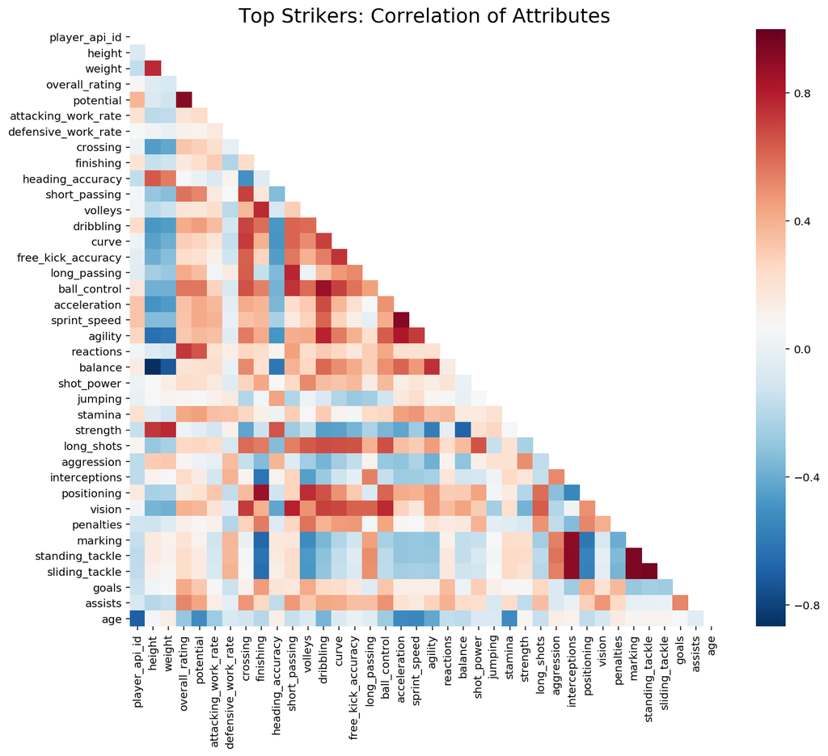

```python
# Get correlation values across top strikers attributes and stats
corr = strikers.corr()

# Generate a mask for the upper triangle
mask = np.zeros_like(corr, dtype=np.bool)
mask[np.triu_indices_from(mask)] = True

# Plot correlation heatmap
fig0, ax0 = plt.subplots(figsize=(12, 10))
sns.heatmap(corr, mask=mask, cmap="RdBu_r")
ax0.set_title('Top Strikers: Correlation of Attributes', fontsize=18)
```

It looks like there is a variety attributes that are positively correlated with number of goals a player scores, as well as some attributes that are neagtively correlated with goals scored.

At first glance, *finishing, volleys, ball_control, recations, shot_power, positioning, and penalties* appear to be the most strongly correlated with the number of goals a player scores.

We will be focusing on how a striker's *age* affects their *overall_rating* and *potential*. At first glance of the heatmap above, it is seems that *age* is negatively correlated with both *overall_rating* and *potential*. But to what degree? Are we confident that *age* is a good predictor of *overall_rating* or *potential*? Let's explore this more below.

### Research Question 1: How Does Age Affect Strikers?

One might expect that a striker will mature with age leading to a rise in overall rating as they gain experience, but do players start to recede in skill at a certain age? Similarly, how does player potential change as strikers age? One might guess that potential decreases with age.

**Hypothesis 1:** *Overall_rating* varies linearly with age, as a player gets older, they improve.

**Hypothesis 2:** Player *potential* reduces with age.

#### Age vs. Overall Rating

We will start using a hexbin plot as it gives us a good idea of how the distributions of *age* and *overall_rating* overlap with one another (both range and density). A scatter plot might be a tempting first attempt of gaining some insight, but a scatter makes it hard to know how many players exist a specific *age* & *overall_rating* pairing.

**Note:**  
The formatting lines to get the colorbar for the density of points to display correctly were found [here](https://stackoverflow.com/questions/29096632/getting-legend-in-seaborn-jointplot). Some minor modifications were made to account for compatitbilty with this code.

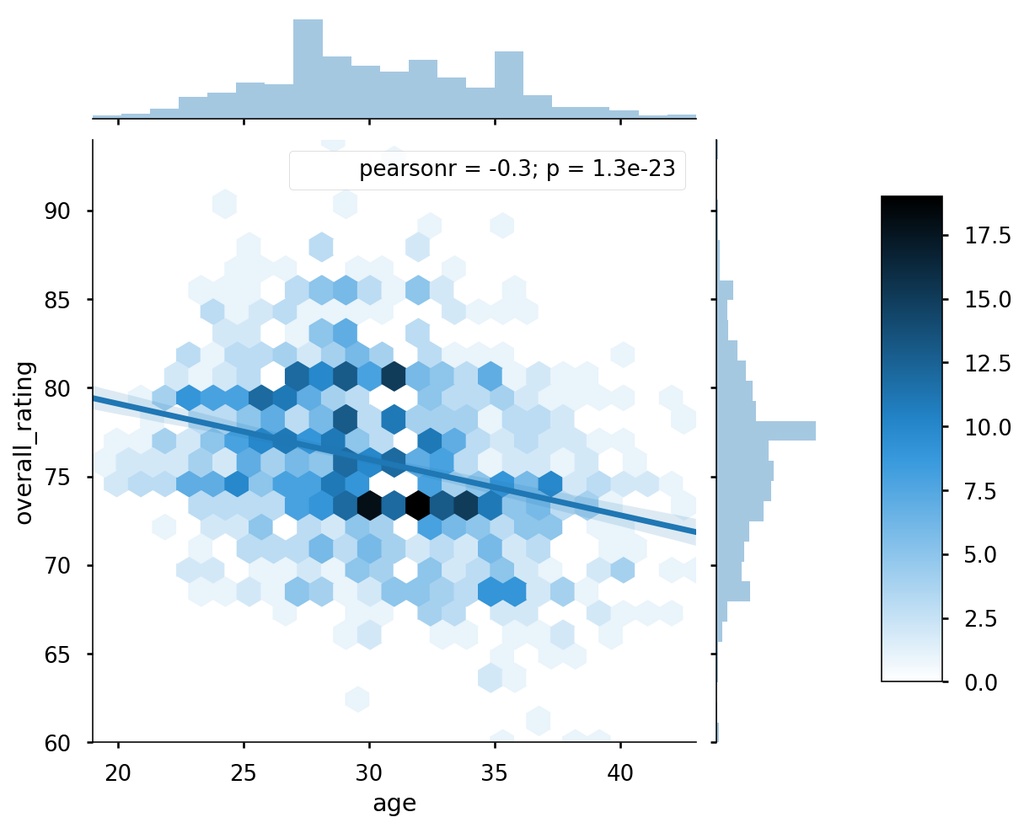

```python
sns.set_context("talk")    # scale plot elements
hexplot = sns.jointplot(x='age', y='overall_rating', data=strikers, kind='hex', size=10)    # hexbin plot

plt.subplots_adjust(left=0.2, right=0.8, top=0.8, bottom=0.2)  # shrink figure so cbar is visible to right
cax = hexplot.fig.add_axes([.85, .25, .05, .4])  # colorbar axes x position, y position, width, height
plt.colorbar(cax=cax)

sns.regplot(x='age', y='overall_rating', data=strikers, ax=hexplot.ax_joint, scatter=False)    # add linear reg. line
```

```python
# calculate R^2 value based on R, for print below
r_squared = stats.pearsonr(strikers['age'], strikers['overall_rating'])[0] ** 2

print("R-squared =", r_squared)
```

```
R-squared = 0.0872278247402
```

Based on a linear regression of the data, it is actually expected that the *overall_rating* for a striker would decrease with *age*. However, the linear regression poorly fits the data with a coefficient of determination (R-squared) of 0.09. This means that only 9% of the variance in overall_rating is predicted by a player's age. It is likely that other factors are influencing a strikers overall rating, and cannot be well explained by age alone. Based on this information it is reasonable to **reject Hypothesis 1**.

From a more qualitative veiwpoint, most strikers with an overall rating of 85 or higher are found in the age range of 25 to 35 years old. This suggests that for the best strikers in the pro leagues, there is a prime age for top performers, though this dynamic is not well captured by a linear relationship.

#### Age vs Player Potential

Let's take a look at how player potential varies with age for strikers. Let's start off with another hexbin plot as it captures both the spread and the density of value pairs for *age* and *potential*.

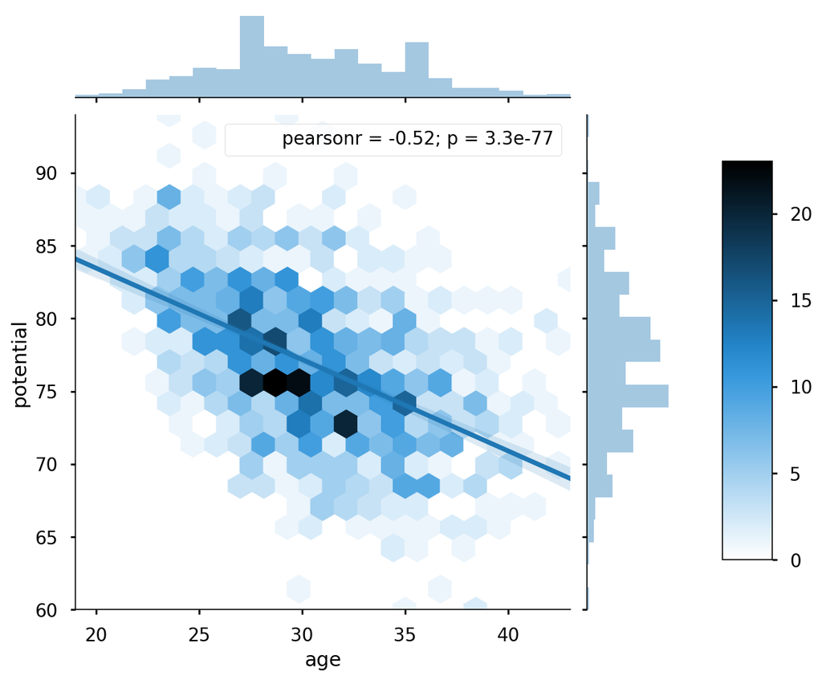

```python
sns.set_context("talk")    # scale plot elements
hexplot = sns.jointplot(x='age', y='potential', data=strikers, kind='hex', size=10)    # hexbin plot

plt.subplots_adjust(left=0.2, right=0.8, top=0.8, bottom=0.2)  # shrink figure so cbar is visible to right
cax = hexplot.fig.add_axes([.85, .25, .05, .4])  # colorbar axes x position, y position, width, height
plt.colorbar(cax=cax)

sns.regplot(x='age', y='potential', data=strikers, ax=hexplot.ax_joint, scatter=False)    # add linear reg. line
```

```python
# calculate R^2 value based on R, for print below
r_squared = stats.pearsonr(strikers['age'], strikers['potential'])[0] ** 2

print("R-squared =", r_squared)
```

```
R-squared = 0.269932134334
```

As expected, a player's *potential* generally decreases as their *age* increases. This trend is shown by the best fit line. The denser (darker) regions of the hexpbin plot also exhibit a general trend of decreasing potential with age (with some variation of course).

As with the *age* vs *overall_rating*, the linear relationship is not extremely strong across the entire dataset of strikers (though considerably stronge than *age* vs *overall_rating*), with a coefficient fo determination of 0.27. In other words, 27% of the variation in a player's potential is predicted by a player's age. Similar to *overall_rating*, there are likely other factors in addition to age that are affecting player potential.

What about the difference in *overall_rating* and *potential*, or what we could call *remaining_potential*, as players get older. At this stage in our analysis it seems that this might be what our question was really getting at... does the difference between *overall_rating* and *potential* trend towards zero as a player gets older?

**Perhaps we should revise Hypthesis 2 to read:** Does a player's *remaining_potential* (*overall_rating* and *potential*) trend toward zero as they get older?

The answer to our revised Hypothesis 2 could be useful for team managers. It seems logical that having a general understanding of the age at which *most* (not all) players reach their potential would help when making personnel choieces. For example, this would be helpful when aquiring players from other teams or as free agents and when deciding bewtween two players of similar skill but at different ages.

Naturally, our first step in answering this question will be to calculate the *remaining_potential* for each player.

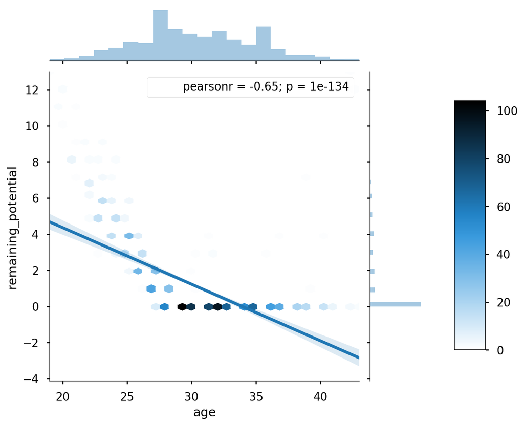

```python
strikers['remaining_potential'] = strikers.potential - strikers.overall_rating    # calc. remaining potential

sns.set_context("talk")    # scale plot elements
hexplot = sns.jointplot(x='age', y='remaining_potential',
                        data=strikers, kind='hex', size=10)    # hexbin plot

plt.subplots_adjust(left=0.2, right=0.8, top=0.8, bottom=0.2)  # shrink figure so cbar is visible to right
cax = hexplot.fig.add_axes([.85, .25, .05, .4])  # colorbar axes x position, y position, width, height
plt.colorbar(cax=cax)

sns.regplot(x='age', y='remaining_potential', data=strikers,
            ax=hexplot.ax_joint, truncate=True, scatter=False)    # add linear reg. line
```

Hmmmm... although the hexbin plot using **jointplot( )** gives us a idea of ditribution of *age* vs *remaining_potential*, the linear regression using **regplot( )** doesnt make much sense upon visual inspection.

The large number of zero values for *remaining_potential* for players older than 30 seems to be skewing the regression, let's remove these data points from the regression in **regplot( )** along with a few outlying values for high *remaining_potential* at older ages (>30), which are a rare occurrence.

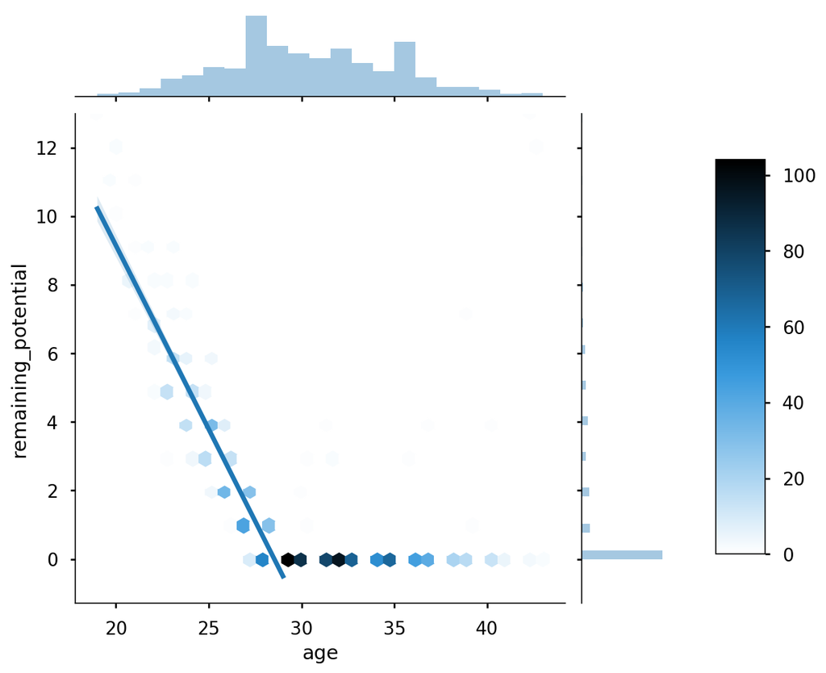

```python
strikers['remaining_potential'] = strikers.potential - strikers.overall_rating

sns.set_context("talk")    # scale plot elements
hexplot = sns.jointplot(x='age', y='remaining_potential',
                        data=strikers, kind='hex', stat_func=None, size=10)    # hexbin plot

plt.subplots_adjust(left=0.2, right=0.8, top=0.8, bottom=0.2)  # shrink figure so cbar is visible to right
cax = hexplot.fig.add_axes([.85, .25, .05, .4])  # colorbar axes x position, y position, width, height
plt.colorbar(cax=cax)

strikers_with_potential = strikers[strikers.age < 30]

sns.regplot(x='age', y='remaining_potential', data=strikers_with_potential,
            ax=hexplot.ax_joint, truncate=True, scatter=False)    # add linear reg. line
```

```python
# calculate R^2 value based on R, for print below
r_squared = stats.pearsonr(strikers_with_potential['age'], strikers_with_potential['remaining_potential'])[0] ** 2

print("R-squared =", r_squared)
```

```
R-squared = 0.89154895711
```

This is more insightful, after removing players older than 30, where the *remaining_potential* is more often 0 than not, we see a strongly linear relationship between *age* and *remaining_potential*. By age 30 there appears to be little chance for a player to have any *remaining_potential* (*potential* - *overall_rating*), with *remaining_potential* typically highest when players enter the league.

Based on the above analysis, we can accept our revised Hypthesis 2 and state that *remaining_potential* (what we are really interested) decreases with age.

### Research Question 2 : What are the attributes that are most strongly correlated with the players who have the most assits? What 2 attributes would you look for the most for in player you wanted to have a lot of assists?

To start, let us take a look at the heatmap for the top 10% of passers who make that crucial last pass to the scorer. What makes them tick?

```
Text(0.5,1,'Top Passers: Correlation of Player Attributes')
```

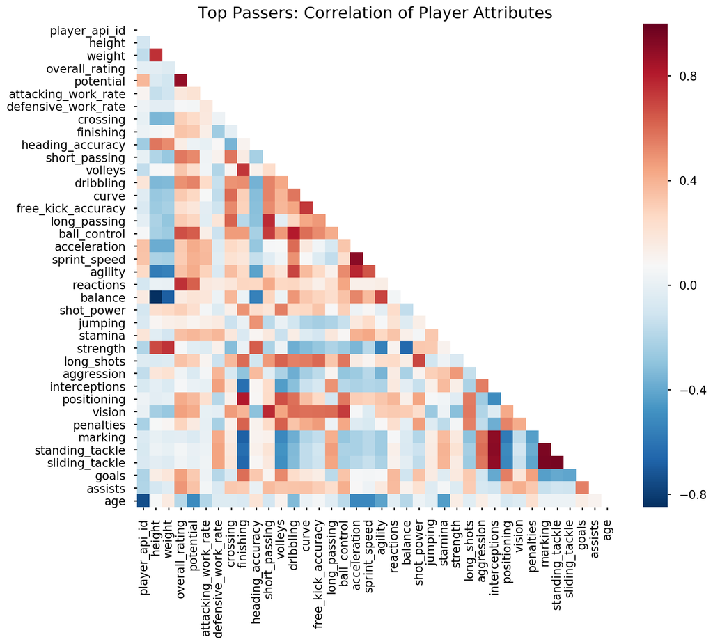

```python
# get correlation values across all player attributes and stats
corr = passers.corr()

# Generate a mask for the upper triangle
mask = np.zeros_like(corr, dtype=np.bool)
mask[np.triu_indices_from(mask)] = True

fig1, ax1 = plt.subplots(figsize=(12, 10))
sns.heatmap(corr, mask=mask, cmap="RdBu_r")
ax1.set_title('Top Passers: Correlation of Player Attributes', fontsize=18)
```

Judging by the heatmap, it looks like *overall_rating, potential, crossing, finishing, short_passing, volleys, dribbling, curve, free_kick_accuracy, long_passing, ball_control, reactions, shot_power, long_shots, positioning, vision, penalties, and goals* are all well correlated with players who have a high number of assists.

It's a bit hard to distinguish what attributes are the most strongly correlated with a lot of assists (apart from the most obvious ones), so let's see if we can get the actual correlation values for each player attributes so we can determine the top attributes.

We will remove the negatively correlated attributes and attributes which clearly aren't associated with making passes or assists.

```python
# get subset of correlations for only the assists row with positive values

assists_corr = corr.loc['assists',:]    # get only the assists row
assists_corr = assists_corr[assists_corr > 0]   # remove correlations less than zero

# lets remove the columns that are stats, or attributes not related to passing
assists_corr.drop(['goals', 'assists', 'long_shots', 'finishing',
                   'penalties', 'overall_rating', 'potential'], inplace=True)

assists_corr    # check that negative correlations and unwanted columns are removed
```

```
attacking_work_rate    0.134800
crossing               0.477926
short_passing          0.472317
volleys                0.319550
dribbling              0.427983
curve                  0.420007
free_kick_accuracy     0.344479
long_passing           0.347499
ball_control           0.486324
acceleration           0.211096
sprint_speed           0.158443
agility                0.282522
reactions              0.401337
balance                0.245524
shot_power             0.222672
stamina                0.234451
interceptions          0.005343
positioning            0.290936
vision                 0.480389
standing_tackle        0.000608
sliding_tackle         0.007794
Name: assists, dtype: float64
```

Good, now we have a Series of all the attributes positively correlated with the numebr of assists a player makes.

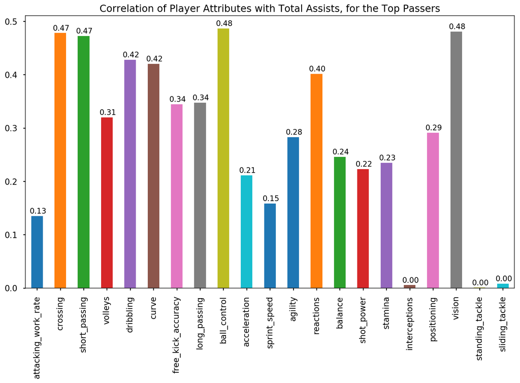

```python
fig, ax = plt.subplots(figsize=(14,8))    # setup figure and axis
assists_corr.plot(kind='bar', x=assists_corr.index, y=assists_corr)    # bar plot of correlations

ax.set_title("Correlation of Player Attributes with Total Assists, for the Top Passers")

# loop through each patchs and print the correlation value
for p in ax.patches:
    val = str(p.get_height())    # get value as a string
    val = val[:4]                # get sub string

    ax.annotate(val, (p.get_x() - 0.075, p.get_height() + 0.005), fontsize =12)    # print values above each bar
```

If I was looking for a player to make a lot of assists on my team, in order to help out my team's striker(s), I would look first look for players with strong ball control and vision compared to other potential candidates.

It should be noted that the correlation of these attributes (none exceed R = 0.48) suggests that no single attribute fully predicts the the number of assists a player will have based on a linear relationship.

## Conclusions

To become an elite striker or passer in the pro football/soccer leagues, players must master a large amount of skills.

### Results of Analysis

The effect of a strikers (defined as the top 10% of goal scorers) age on their overall rating and remaining potential was investigated. It was found that a strikers age was not a good indicator of the overall rating of a striker (R-sqaured = 0.09), but qualitative results suggest that the best strikers acheive their highest overall rating during the ages of 25 to 35. Striker age was found to be a reasonable indicator of the remaining potential of a striker (R-squared = 0.89). Generally, strikers have reached there maximum potential by age 30.

The professional players who have the most assists (called top passers in this analysis) typically have higher ball control and vision relative to their peers, though as stated earlier, the best players must master a wide skill set and no one attribute solely predicts a player's potential for assists over their career. As always, correlation should not be confused with causation!

### Caveats

Caveats to this analysis include an incomplete record of match goal and assist data. This missing goal/assist data possibly results in some players appearing to be better than they are relative to their peers (i.e., more of their goals happened to be recorded) or worse relative to thier peers (i.e., less of their goals happened to be recorded). Additionally, the player attributes used in this analysis are from EA Sports FIFA player ratings, the process for the determination of these player attribute values is not known. These attribute values could be called into question, especially if there is some human factor in assigning the values that is not based in actual game play statistics. Further reasearch into how these player attribute values are determined would help in our understanding of the data.

### Possible Future Work

Future work or improvements based on or related to this analysis could include the evaluation of higher order relationships between player overall_rating and age, which were not well defined by a linear relationship. Also, filtering the goal scorers and players with assists by position might improve the correlation between attributes and goals scored or assists made, since a players position is likely to have some effect on their probability to score or make the final pass before a goal. Comparing the players by exact position might lead to a better apples-to-apples comaprison of goal scorers and passers.